# 2502151-OmerFarukKale-497Project

3- Let’s split data as train and test

```r
test_size <- 12

train_data <- head(ts_jpn, -test_size)
test_data <- tail(ts_jpn,test_size)


length(train_data)
```

```
## [1] 635
```

```r
length(test_data)
```

```
## [1] 12
```

4- Anomaly Detection

```r
library(tibbletime)
library(tidyverse)
library(timetk)
library(anomalize)
```

```
## frequency = 12 months
## trend = 60 months
```

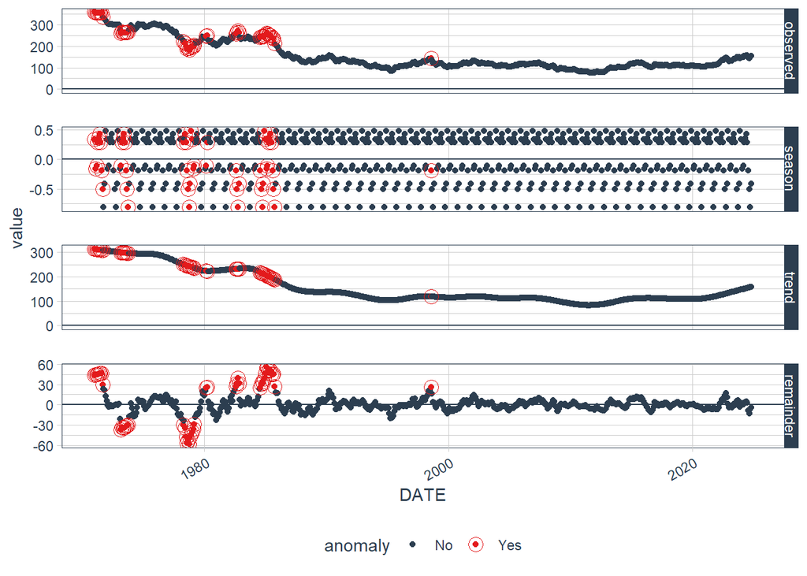

```r
library(dplyr)
library(forecast)
jpn$DATE <- as.Date(jpn$DATE, format = "%Y-%m-%d")
jpn_tt <- as_tbl_time(jpn, index = DATE)

jpn_tt %>% anomalize::time_decompose(EXJPUS, method = "stl", frequency = "auto", trend = "auto") %>% anomalize::anomalize(remainder, method = "gesd", alpha = 0.05, max_anoms = 0.2) %>% anomalize::plot_anomaly_decomposition()
```

```r
traindata_clean<-tsclean(train_data)

#visualizing the check whether there are anomalies or not
#in my graph there is anomalies so we should extract these anomalies.
```

As we can see from the visualizations there is anomalies we should try to reduce number of anomlies.

```
## frequency = 12 months
```

```
## trend = 60 months
```

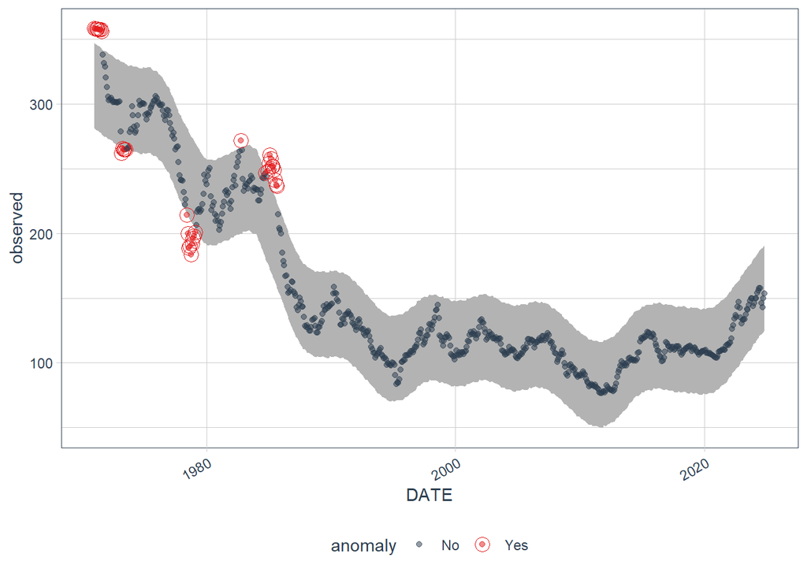

```r
jpn_tt %>%
  anomalize::time_decompose(EXJPUS) %>%
  anomalize::anomalize(remainder) %>%
  anomalize::time_recompose() %>%
  anomalize::plot_anomalies(time_recomposed = TRUE, ncol = 3, alpha_dots = 0.5)
```

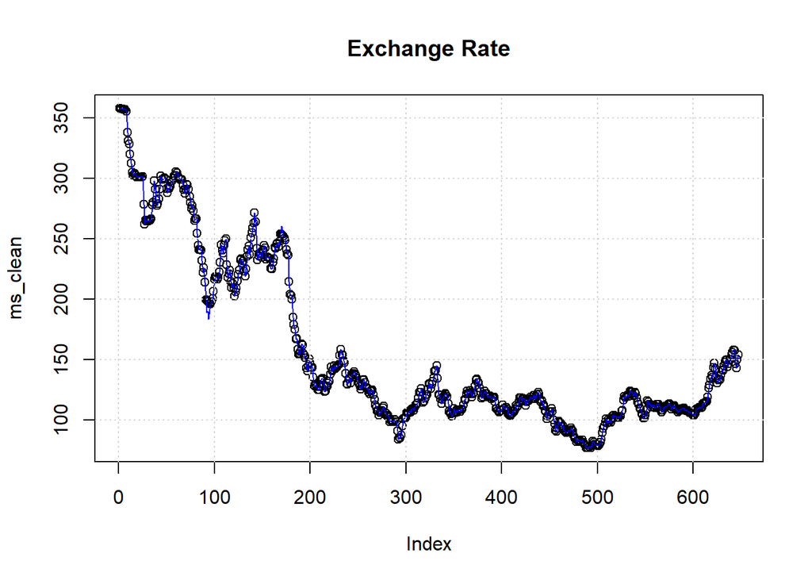

```r
ms_clean=tsclean(jpn$EXJPUS)
plot(ms_clean, main="Exchange Rate")
lines(jpn$EXJPUS, col='blue') #original dataset.
grid()
```

We use tsclean function to clean anomalies from our data.

5- BoxCox transformation

```r
library(MASS)
lambda <- BoxCox.lambda(traindata_clean)
lambda
```

```
## [1] -0.2997624
```

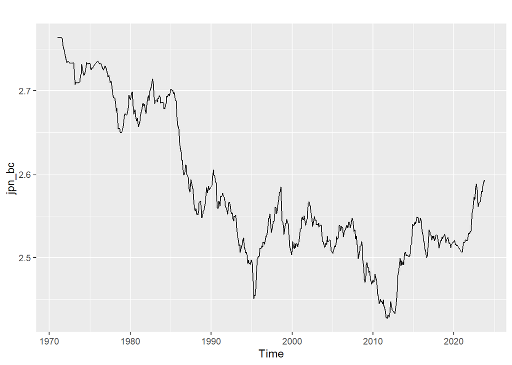

```r
jpn_bc <- BoxCox(traindata_clean,lambda)

autoplot(jpn_bc)
```

To make variance more stable we did a BoxCox transformation. Since lambda is not high we don’t need to do BoxCox.

6- ACF and PACF plotting and then testing

```r
library(gridExtra)
```

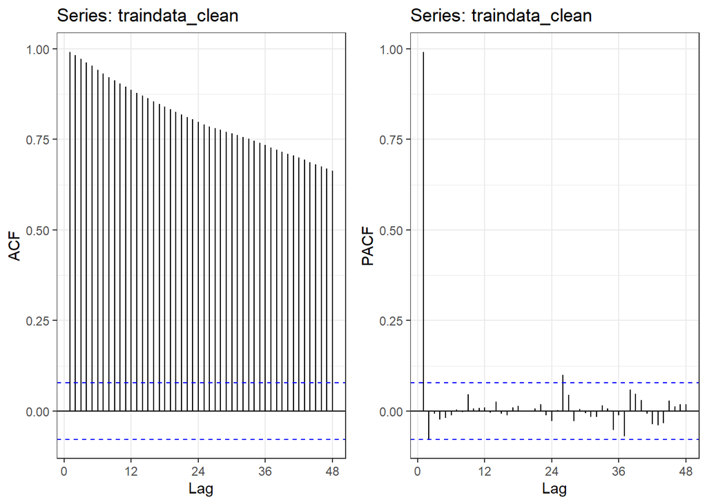

```r
p1<-ggAcf(traindata_clean,lag.max = 48)+theme_bw()
p2<-ggPacf(traindata_clean, lag.max = 48)+theme_bw()
grid.arrange(p1,p2,nrow=1)
```

Since in ACF plot there is slow linear decay we can say that our model is not stationary. We should conduct tests also to be sure.

```r
library(tseries)
kpss.test(traindata_clean,null="Level")
```

```
##
##  KPSS Test for Level Stationarity
##
## data:  traindata_clean
## KPSS Level = 6.7074, Truncation lag parameter = 6, p-value = 0.01
```

According to this result we should reject h0 accept h1 and that means model is not stationary.

```r
kpss.test(traindata_clean,null="Trend")
```

```
##
##  KPSS Test for Trend Stationarity
##
## data:  traindata_clean
## KPSS Trend = 1.7339, Truncation lag parameter = 6, p-value = 0.01
```

We should also reject h0,and accept h1 so that means there is stochastic trend.

Let’s apply adf test to check whether there is unit root or not

```r
library(fUnitRoots)

adfTest(traindata_clean,lags = 2,type = "c")
```

```
##
## Title:
##  Augmented Dickey-Fuller Test
##
## Test Results:
##   PARAMETER:
##     Lag Order: 2
##   STATISTIC:
##     Dickey-Fuller: -3.0993
##   P VALUE:
##     0.02795
##
## Description:
##  Sat Jan 18 23:41:41 2025 by user: Lenovo
```

```r
adfTest(traindata_clean,lags = 2,type = "ct")
```

```
##
## Title:
##  Augmented Dickey-Fuller Test
##
## Test Results:
##   PARAMETER:
##     Lag Order: 2
##   STATISTIC:
##     Dickey-Fuller: -1.8783
##   P VALUE:
##     0.6298
##
## Description:
##  Sat Jan 18 23:41:41 2025 by user: Lenovo
```

Our p value is bigger than 0.05 so fail to reject h0 that means there is stochastic trend.

let’s apply HEGY test to be check whether there is seasonal unit root or not.

```r
library(pdR)
test_hegy <- HEGY.test(wts=traindata_clean, itsd=c(1,1,0), regvar=0, selectlags=list(mode="signf", Pmax=NULL))
test_hegy$stats
```

```
##               Stat. p-value
## tpi_1     -1.059902    0.10
## tpi_2     -6.581055    0.01
## Fpi_3:4   35.208831    0.01
## Fpi_5:6   50.169066    0.01
## Fpi_7:8   55.231945    0.01
## Fpi_9:10  40.912052    0.01
## Fpi_11:12 40.322127    0.01
## Fpi_2:12  50.239638      NA
## Fpi_1:12  46.667061      NA
```

As we can see from the result we can say that there is only one unit root and it is normal unit root. Since p value of Fpi_11;12 is smaller than 0.05, reject h0 which means that there is no seasonal unit root. But for tpi_1 part, it is bigger than 0.05 so fail to reject h0 which means there is normal unit root.

7-Taking difference and making tests

```r
diff_jpn_bc <- diff(traindata_clean)
kpss.test(diff_jpn_bc,null = c("Level"))
```

```
##
##  KPSS Test for Level Stationarity
##
## data:  diff_jpn_bc
## KPSS Level = 0.54138, Truncation lag parameter = 6, p-value = 0.03235
```

to be sure and check whether there is still unit root or not let’s look adftest

```r
adfTest(diff_jpn_bc,lags = 2,type = "c")
```

```
##
## Title:
##  Augmented Dickey-Fuller Test
##
## Test Results:
##   PARAMETER:
##     Lag Order: 2
##   STATISTIC:
##     Dickey-Fuller: -12.0432
##   P VALUE:
##     0.01
##
## Description:
##  Sat Jan 18 23:41:42 2025 by user: Lenovo
```

Since p value is smaller than 0.05 we are rejecting h0 so there is no unit root anymore.

one differencing is enough but let’s check hegy test to be certain.

```r
diffTestHegy<- HEGY.test(wts=diff_jpn_bc, itsd=c(1,1,0), regvar=0, selectlags=list(mode="signf", Pmax=NULL))
diffTestHegy$stats
```

```
##               Stat. p-value
## tpi_1     -6.348789    0.01
## tpi_2     -7.517849    0.01
## Fpi_3:4   39.902501    0.01
## Fpi_5:6   33.981005    0.01
## Fpi_7:8   31.428275    0.01
## Fpi_9:10  37.132586    0.01
## Fpi_11:12 30.512564    0.01
## Fpi_2:12  48.177605      NA
## Fpi_1:12  49.797490      NA
```

```r
library(uroot)
ch.test(jpn_bc,type = "dummy",sid=c(1:12))
```

```
##
##  Canova and Hansen test for seasonal stability
##
## data:  jpn_bc
##
##      statistic pvalue
## [1,]    2.9599   0.05 .
## ---
## Signif. codes: 0 '***' 0.001 '**' 0.01 '*' 0.05 '.' 0.1 ' ' 1
##
## Test type: seasonal dummies
## NW covariance matrix lag order: 19
## First order lag: no
## Other regressors: no
## P-values: interpolation in original tables
```

8-

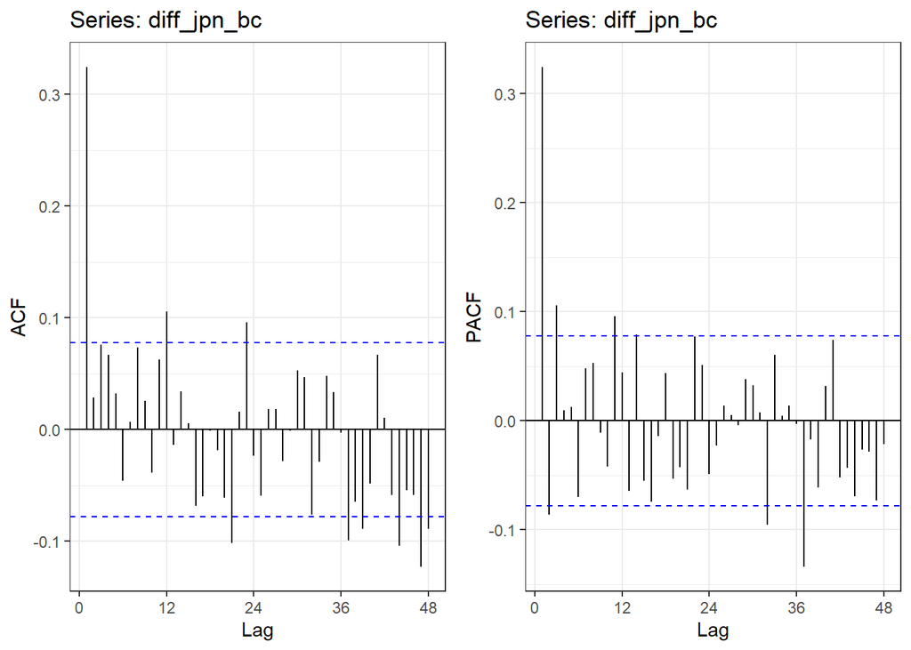

```r
pp1<-ggAcf(diff_jpn_bc,lag.max = 48)+theme_bw()
pp2<-ggPacf(diff_jpn_bc,lag.max = 48)+theme_bw()
grid.arrange(pp1,pp2,nrow=1)
```

When we look to the ACF and PACF plots there is sinusodial behaviour in ACF and PACF plot. It may be okay to use ARIMA(1,1,1) or ARIMA(1,1,0) according to the plots.But there might be slight seasonality.

```r
library(TSA)
```

```r
eacf(diff_jpn_bc,ar.max = 24,ma.max = 24)
```

```
## AR/MA
##    0 1 2 3 4 5 6 7 8 9 10 11 12 13 14 15 16 17 18 19 20 21 22 23 24
## 0  x o o o o o o o o o o  x  o  o  o  o  o  o  o  o  x  o  x  o  o
## 1  x x o o o o o o o o o  x  o  o  o  o  o  o  o  o  x  o  x  o  o
## 2  x x x o o o o o o o o  x  o  o  o  o  o  o  o  o  o  o  o  o  o
## 3  x x x o o o o o o o o  x  o  o  o  o  o  o  o  o  o  o  o  o  o
## 4  x o x x o o o o o o o  x  o  o  o  o  o  o  o  o  o  o  o  o  o
## 5  x x x x x o o o o o o  x  o  o  o  o  o  o  o  o  o  o  o  o  o
## 6  x x x x x o o o o o o  x  o  o  o  o  o  o  o  o  o  o  x  o  o
## 7  x x o x x x o o o o o  x  o  o  o  o  o  o  o  o  o  o  o  o  o
## 8  x x o x x x o o o o o  x  o  o  o  o  o  o  o  o  o  o  o  o  o
## 9  x x x x x o x o o x o  o  o  o  o  o  o  o  o  o  o  o  o  o  o
## 10 x x x x o o x o x x o  o  o  o  o  o  o  o  o  o  o  o  o  o  o
## 11 x x x x x x x x x x x  o  o  o  o  o  o  o  o  o  o  o  o  o  o
## 12 x o x x x o x x x o x  o  o  o  o  o  o  o  o  o  o  o  o  o  o
## 13 x o o x x o o x x x o  x  o  x  o  o  o  o  o  o  o  o  o  o  o
## 14 x x o x x x o x x x o  x  x  x  o  o  o  o  o  o  o  o  o  o  o
## 15 x x o x x x x x o x x  x  x  x  o  o  o  o  o  o  o  o  o  o  o
## 16 x x o x x o x o o x x  o  x  x  x  o  o  o  o  o  o  o  o  o  o
## 17 x x x x x o x o x o x  o  o  x  o  o  o  o  o  o  o  o  o  o  o
## 18 x x x x x x x x x o x  x  o  x  x  o  o  o  o  o  o  o  o  o  o
## 19 x x x x x x x x x x x  x  o  x  o  o  o  o  o  o  o  o  o  o  o
## 20 x x x x x x x x x x o  x  o  x  o  o  o  o  x  o  o  o  o  o  o
## 21 x x x x o o o x x x x  o  x  x  o  o  o  o  o  o  o  o  o  o  o
## 22 x x x x o o o o o x x  o  x  o  o  o  o  o  x  o  o  o  o  o  o
## 23 x x x x o o o o o x o  x  o  o  o  o  o  o  x  o  o  x  o  o  o
## 24 x x x x o o o o o x o  x  o  x  x  o  o  o  x  o  o  o  o  o  o
```

It is hard to choose a model from here because it is not quite okay for our model.

9- I think the best model is ARIMA(11,1,0) by looking to the ACF and PACF plots.

10-

```r
library(forecast)
auto.arima(jpn_bc)
```

```
## Series: jpn_bc
## ARIMA(1,1,0)(0,0,1)[12]
##
## Coefficients:
##          ar1    sma1
##       0.3153  0.0669
## s.e.  0.0378  0.0417
##
## sigma^2 = 3.078e-05:  log likelihood = 2394.66
## AIC=-4783.32   AICc=-4783.28   BIC=-4769.96
```

ARIMA(1,1,2) ARIMA(1,1,1) ARIMA(1,1,0) ARIMA(1,1,6) ARIMA(11,1,0) ARIMA(11,1,1) ARIMA(11,1,6) ARIMA(11,1,2) ARIMA(8,1,1) ARIMA(1,1,0)(0,0,1)[12]

```r
fit1<-Arima(traindata_clean,order = c(1, 1, 2))
fit1
```

```
## Series: traindata_clean
## ARIMA(1,1,2)
##
## Coefficients:
```

```
##          ar1     ma1      ma2
##       0.1685  0.2033  -0.0603
## s.e.     NaN     NaN      NaN
##
## sigma^2 = 16.52:  log likelihood = -1787.22
## AIC=3582.43   AICc=3582.49   BIC=3600.24
```

```r
fit2<-Arima(traindata_clean,order = c(1, 1, 1))
fit2
```

```
## Series: traindata_clean
## ARIMA(1,1,1)
##
## Coefficients:
##          ar1     ma1
##       -0.031  0.3990
## s.e.   0.124  0.1161
##
## sigma^2 = 16.49:  log likelihood = -1787.19
## AIC=3580.37   AICc=3580.41   BIC=3593.73
```

```r
fit3<-Arima(traindata_clean,order = c(1, 1, 0))
fit3 #
```

```
## Series: traindata_clean
## ARIMA(1,1,0)
##
## Coefficients:
##          ar1
##       0.3281
## s.e.  0.0375
##
## sigma^2 = 16.68:  log likelihood = -1791.34
## AIC=3586.69   AICc=3586.71   BIC=3595.59
```

```r
fit4<-Arima(traindata_clean,order = c(1, 1, 6))
fit4
```

```
## Series: traindata_clean
## ARIMA(1,1,6)
##
## Coefficients:
##          ar1     ma1      ma2     ma3     ma4     ma5      ma6
##       0.2522  0.1127  -0.0763  0.0685  0.0349  0.0364  -0.0407
## s.e.  0.5904  0.5891   0.2187  0.0419  0.0572  0.0488   0.0465
##
## sigma^2 = 16.46:  log likelihood = -1784.1
## AIC=3584.21   AICc=3584.44   BIC=3619.82
```

```r
fit5<-Arima(traindata_clean,order = c(11, 1, 0))
fit5 #
```

```
## Series: traindata_clean
## ARIMA(11,1,0)
##
## Coefficients:
##          ar1      ar2     ar3      ar4     ar5      ar6     ar7     ar8     ar9
##       0.3686  -0.1161  0.1051  -0.0128  0.0492  -0.0819  0.0339  0.0452  0.0178
## s.e.  0.0395   0.0420  0.0422   0.0424  0.0424   0.0423  0.0423  0.0428  0.0426
##          ar10    ar11
##       -0.0765  0.1016
## s.e.   0.0424  0.0400
##
## sigma^2 = 16.26:  log likelihood = -1778.29
## AIC=3580.58   AICc=3581.08   BIC=3634.01
```

```r
fit6<-Arima(traindata_clean,order = c(11, 1, 1))
fit6
```

```
## Series: traindata_clean
## ARIMA(11,1,1)
##
## Coefficients:
##          ar1      ar2     ar3      ar4     ar5      ar6     ar7     ar8     ar9
##       0.6049  -0.2022  0.1322  -0.0392  0.0516  -0.0917  0.0522  0.0373  0.0050
## s.e.  0.2766   0.1100  0.0566   0.0558  0.0470   0.0481  0.0515  0.0481  0.0498
##          ar10    ar11      ma1
##       -0.0788  0.1136  -0.2389
## s.e.   0.0465  0.0402   0.2773
##
## sigma^2 = 16.27:  log likelihood = -1777.93
## AIC=3581.86   AICc=3582.45   BIC=3639.74
```

```r
fit7<-Arima(traindata_clean,order = c(11, 1, 6))
fit7
```

```
## Series: traindata_clean
## ARIMA(11,1,6)
##
## Coefficients:
##          ar1      ar2     ar3      ar4     ar5      ar6     ar7      ar8
##       0.6624  -0.4293  1.2044  -0.6787  0.4451  -1.0771  0.4104  -0.1449
## s.e.  0.0656   0.1086  0.1062   0.1195  0.1104   0.0957  0.0766   0.0724
##          ar9     ar10    ar11      ma1     ma2      ma3     ma4      ma5
##       0.1292  -0.0968  0.0931  -0.3068  0.2182  -1.0239  0.2585  -0.1898
## s.e.  0.0547   0.0595  0.0440   0.0544  0.0886   0.0701  0.0790   0.0644
##          ma6
##       0.8973
## s.e.  0.0715
##
## sigma^2 = 15.76:  log likelihood = -1767.65
## AIC=3571.3   AICc=3572.41   BIC=3651.43
```

```r
fit8<-Arima(traindata_clean,order = c(11, 1,2))
fit8 #
```

```
## Series: traindata_clean
## ARIMA(11,1,2)
##
## Coefficients:
```

```
##           ar1      ar2     ar3      ar4     ar5      ar6     ar7     ar8
##       -0.3041  -0.5208  0.2681  -0.0164  0.1130  -0.0569  0.0112  0.0164
## s.e.      NaN   0.1049  0.0573   0.0411  0.0479   0.0446  0.0423  0.0478
##          ar9     ar10    ar11     ma1     ma2
##       0.0814  -0.0530  0.0366  0.6782  0.6644
## s.e.  0.0389   0.0446     NaN     NaN     NaN
##
## sigma^2 = 16.18:  log likelihood = -1775.82
## AIC=3579.64   AICc=3580.32   BIC=3641.97
```

```r
#fit9<- Arima(traindata_clean,order = c(37, 1,1))
#fit9
#fit10<- Arima(traindata_clean,order = c(37, 1,12))
#fit10
fit11 <- Arima(traindata_clean,order = c(1, 1,12))
fit11 #
```

```
## Series: traindata_clean
## ARIMA(1,1,12)
##
## Coefficients:
##          ar1     ma1      ma2     ma3     ma4     ma5      ma6      ma7     ma8
##       0.0944  0.2787  -0.0183  0.0631  0.0497  0.0626  -0.0567  -0.0081  0.0885
## s.e.  0.4042  0.4024   0.1570  0.0412  0.0449  0.0443   0.0470   0.0443  0.0458
##          ma9     ma10     ma11    ma12
##       0.0627  -0.0461  -0.0017  0.1525
## s.e.  0.0474   0.0527   0.0481  0.0471
##
## sigma^2 = 16.07:  log likelihood = -1773.62
## AIC=3575.23   AICc=3575.91   BIC=3637.56
```

```r
fit12 <- Arima(traindata_clean,order = c(1, 1,11))
fit12
```

```
## Series: traindata_clean
## ARIMA(1,1,11)
##
## Coefficients:
##           ar1     ma1     ma2     ma3     ma4     ma5      ma6      ma7     ma8
##       -0.6895  1.0754  0.3042  0.0945  0.0917  0.0943  -0.0061  -0.0626  0.0554
## s.e.   0.1523  0.1515  0.0796  0.0614  0.0623  0.0608   0.0572   0.0548  0.0619
##          ma9     ma10     ma11
##       0.0911  -0.0531  -0.1219
## s.e.  0.0661   0.0621   0.0412
##
## sigma^2 = 16.19:  log likelihood = -1776.4
## AIC=3578.79   AICc=3579.38   BIC=3636.67
```

```r
#fit13 <- Arima(traindata_clean,order = c(1, 1,37))
#fit13
#fit14 <-Arima(traindata_clean,order = c(1, 1,38))
#fit14
#fit15<- Arima(traindata_clean,order = c(1, 1,39))
#fit15
fit16 <- Arima(traindata_clean,order = c(1,1,0), seasonal = c(1,0,0))
fit16
```

```
## Series: traindata_clean
## ARIMA(1,1,0)(1,0,0)[12]
##
## Coefficients:
##          ar1    sar1
##       0.3296  0.1177
## s.e.  0.0374  0.0399
##
## sigma^2 = 16.48:  log likelihood = -1787.03
## AIC=3580.07   AICc=3580.11   BIC=3593.43
```

```r
fit17 <- Arima(traindata_clean,order = c(1,1,0), seasonal = c(1,0,1))
fit17 #
```

```
## Series: traindata_clean
## ARIMA(1,1,0)(1,0,1)[12]
##
## Coefficients:
##          ar1     sar1    sma1
##       0.3339  -0.5543  0.6773
## s.e.  0.0375   0.2032  0.1810
##
## sigma^2 = 16.38:  log likelihood = -1784.73
## AIC=3577.46   AICc=3577.52   BIC=3595.26
```

```r
fit18 <- Arima(traindata_clean,order = c(1,1,0), seasonal = c(0,0,1))
fit18 #
```

```
## Series: traindata_clean
## ARIMA(1,1,0)(0,0,1)[12]
##
## Coefficients:
##          ar1    sma1
##       0.3310  0.1325
## s.e.  0.0374  0.0425
##
## sigma^2 = 16.45:  log likelihood = -1786.52
## AIC=3579.04   AICc=3579.08   BIC=3592.39
```

```r
#fit11<- Arima(jpn_bc,order = c(37, 1,6))
#fit11
#I tried to look 37,1,37 but my computer couldn't do it :(

fit19 <- Arima(traindata_clean,order = c(1,1,0), seasonal = c(3,0,3))
fit19
```

```
## Series: traindata_clean
## ARIMA(1,1,0)(3,0,3)[12]
##
## Coefficients:
```

```
##          ar1    sar1    sar2     sar3    sma1     sma2    sma3
##       0.3266  0.1105  0.7597  -0.1826  0.0196  -0.8172  0.0953
## s.e.  0.0359     NaN  0.1743      NaN     NaN   0.1699     NaN
##
## sigma^2 = 16.39:  log likelihood = -1783.87
## AIC=3583.73   AICc=3583.96   BIC=3619.35
```

```r
fit20 <- Arima(traindata_clean,order = c(1,1,1), seasonal = c(1,0,1))
fit20 #
```

```
## Series: traindata_clean
## ARIMA(1,1,1)(1,0,1)[12]
##
## Coefficients:
```

```
##          ar1     ma1     sar1    sma1
##       -0.004  0.3798  -0.5208  0.6458
## s.e.     NaN     NaN      NaN     NaN
##
## sigma^2 = 16.19:  log likelihood = -1780.62
## AIC=3571.24   AICc=3571.34   BIC=3593.5
```

```r
fit21 <- Arima(traindata_clean,order = c(1,1,6), seasonal = c(1,0,1))
fit21
```

```
## Series: traindata_clean
## ARIMA(1,1,6)(1,0,1)[12]
##
## Coefficients:
##          ar1     ma1      ma2     ma3     ma4     ma5      ma6     sar1    sma1
##       0.2188  0.1538  -0.0609  0.0614  0.0294  0.0364  -0.0455  -0.5069  0.6301
## s.e.  0.4893  0.4877   0.1854  0.0427  0.0504  0.0467   0.0453   0.2143  0.1941
##
## sigma^2 = 16.19:  log likelihood = -1777.96
## AIC=3575.91   AICc=3576.27   BIC=3620.43
```

```r
fit22 <- Arima(traindata_clean,order = c(1,1,2), seasonal = c(1,0,1))
fit22#
```

```
## Series: traindata_clean
## ARIMA(1,1,2)(1,0,1)[12]
##
## Coefficients:
##          ar1      ma1      ma2     sar1    sma1
##       0.8258  -0.4435  -0.2787  -0.5418  0.6634
## s.e.  0.1755   0.1828   0.0853   0.2005  0.1792
##
## sigma^2 = 16.18:  log likelihood = -1779.84
## AIC=3571.67   AICc=3571.81   BIC=3598.39
```

```r
fit23 <- Arima(traindata_clean,order = c(3,1,1), seasonal = c(1,0,1))
fit23
```

```
## Series: traindata_clean
## ARIMA(3,1,1)(1,0,1)[12]
##
## Coefficients:
##          ar1      ar2     ar3      ma1     sar1    sma1
##       0.4935  -0.1662  0.1095  -0.1235  -0.5226  0.6439
## s.e.  0.3786   0.1417  0.0482   0.3808   0.2051  0.1851
##
## sigma^2 = 16.17:  log likelihood = -1779.22
## AIC=3572.44   AICc=3572.62   BIC=3603.6
```

```r
fit24 <- Arima(traindata_clean,order = c(3,1,1), seasonal = c(1,0,2))
fit24
```

```
## Series: traindata_clean
## ARIMA(3,1,1)(1,0,2)[12]
##
## Coefficients:
##          ar1      ar2     ar3      ma1     sar1    sma1    sma2
##       0.4818  -0.1620  0.1084  -0.1135  -0.6456  0.7724  0.0307
## s.e.  0.3846   0.1434  0.0489   0.3868   0.3741  0.3750  0.0798
##
## sigma^2 = 16.19:  log likelihood = -1779.12
## AIC=3574.24   AICc=3574.47   BIC=3609.86
```

```r
fit25 <- Arima(traindata_clean,order = c(3,1,1), seasonal = c(0,0,1))
fit25
```

```
## Series: traindata_clean
## ARIMA(3,1,1)(0,0,1)[12]
##
## Coefficients:
##          ar1      ar2     ar3      ma1    sma1
##       0.5174  -0.1751  0.1165  -0.1516  0.1284
## s.e.  0.3574   0.1330  0.0462   0.3598  0.0423
##
## sigma^2 = 16.23:  log likelihood = -1780.73
## AIC=3573.47   AICc=3573.6   BIC=3600.18
```

```r
fit26 <- Arima(traindata_clean,order = c(3,1,0), seasonal = c(0,0,1))
fit26 #
```

```
## Series: traindata_clean
## ARIMA(3,1,0)(0,0,1)[12]
##
## Coefficients:
##          ar1      ar2     ar3    sma1
##       0.3675  -0.1214  0.1040  0.1282
## s.e.  0.0395   0.0418  0.0395  0.0423
##
## sigma^2 = 16.21:  log likelihood = -1780.81
## AIC=3571.63   AICc=3571.72   BIC=3593.89
```

```r
fit27<-Arima(traindata_clean,order = c(3, 1, 1))
fit27
```

```
## Series: traindata_clean
## ARIMA(3,1,1)
##
## Coefficients:
##          ar1      ar2     ar3      ma1
##       0.4875  -0.1651  0.1187  -0.1246
## s.e.  0.3384   0.1257  0.0457   0.3407
##
## sigma^2 = 16.45:  log likelihood = -1785.33
## AIC=3580.66   AICc=3580.76   BIC=3602.92
```

```r
fit28<-Arima(traindata_clean,order = c(3, 1, 0))
fit28
```

```
## Series: traindata_clean
## ARIMA(3,1,0)
##
## Coefficients:
##          ar1      ar2     ar3
##       0.3644  -0.1213  0.1085
## s.e.  0.0394   0.0417  0.0394
##
## sigma^2 = 16.42:  log likelihood = -1785.39
## AIC=3578.78   AICc=3578.85   BIC=3596.59
```

```r
fit29 <- Arima(traindata_clean,order = c(3,1,0), seasonal = c(3,0,1))
fit29
```

```
## Series: traindata_clean
## ARIMA(3,1,0)(3,0,1)[12]
##
## Coefficients:
##          ar1      ar2     ar3     sar1    sar2    sar3    sma1
##       0.3717  -0.1246  0.1034  -0.4268  0.0151  0.0401  0.5538
## s.e.  0.0400   0.0421  0.0402   0.3574  0.0626  0.0544  0.3560
##
## sigma^2 = 16.18:  log likelihood = -1778.92
## AIC=3573.84   AICc=3574.07   BIC=3609.46
```

```r
fit30 <- Arima(traindata_clean,order = c(0,1,1))
fit30
```

```
## Series: traindata_clean
## ARIMA(0,1,1)
##
## Coefficients:
##          ma1
##       0.3711
## s.e.  0.0380
##
## sigma^2 = 16.47:  log likelihood = -1787.22
## AIC=3578.43   AICc=3578.45   BIC=3587.34
```

11-

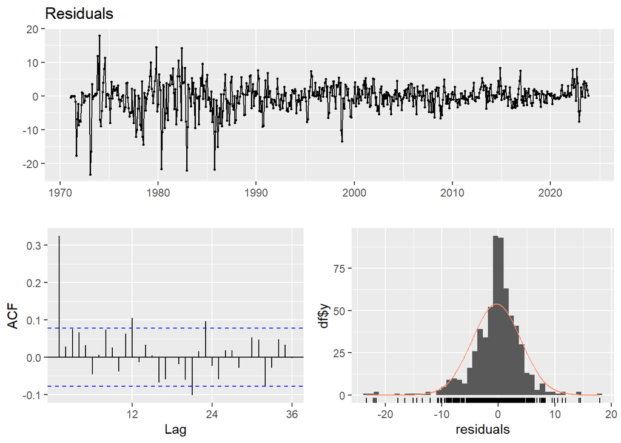

```
##
##  Ljung-Box test
##
## data:  Residuals
## Q* = 113.26, df = 24, p-value = 1.513e-13
##
## Model df: 0.   Total lags used: 24
```

```r
checkresiduals(diff_jpn_bc)
```

Here there are residuals of differenced version.

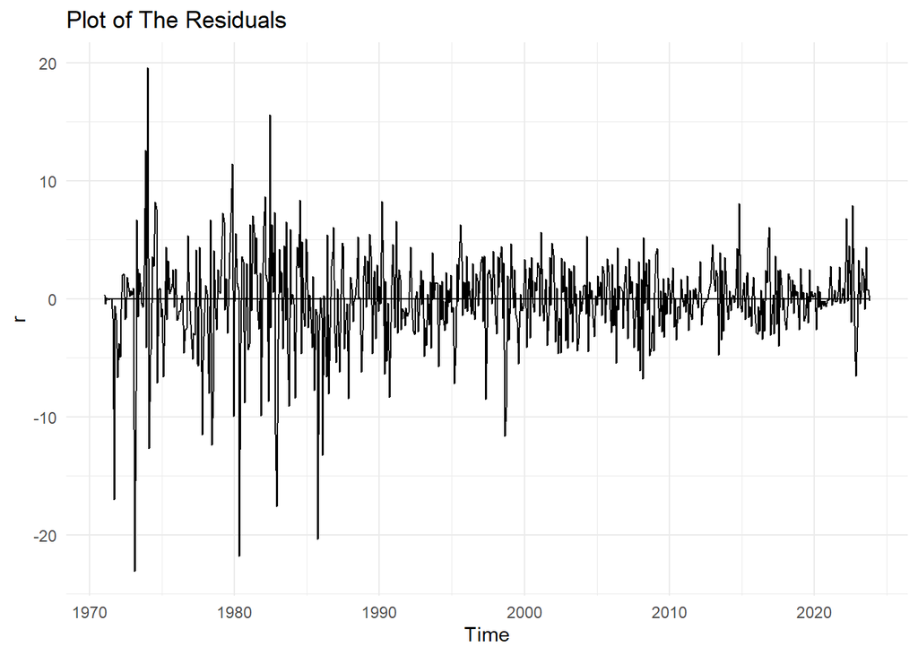

```r
r=resid(fit5)
autoplot(r)+geom_line(y=0)+theme_minimal()+ggtitle("Plot of The Residuals")
```

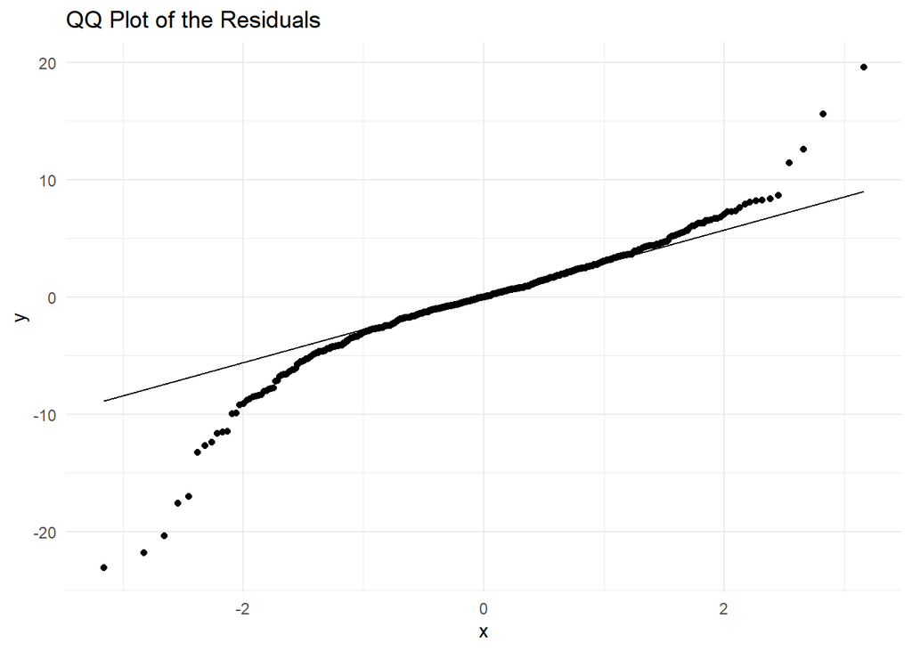

```r
ggplot(r, aes(sample = r)) +stat_qq()+geom_qq_line()+ggtitle("QQ Plot of the Residuals")+theme_minimal()
```

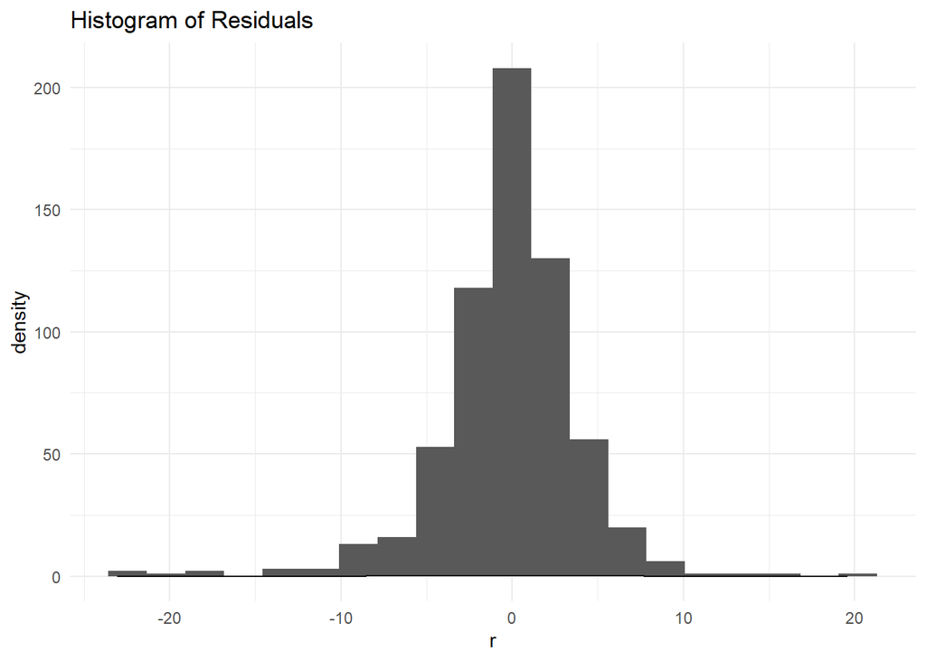

```r
ggplot(r,aes(x=r))+geom_histogram(bins=20)+geom_density()+ggtitle("Histogram of Residuals")+theme_minimal()
```

Histogram of the resiudals shows that the series might be normally distributed residuals.

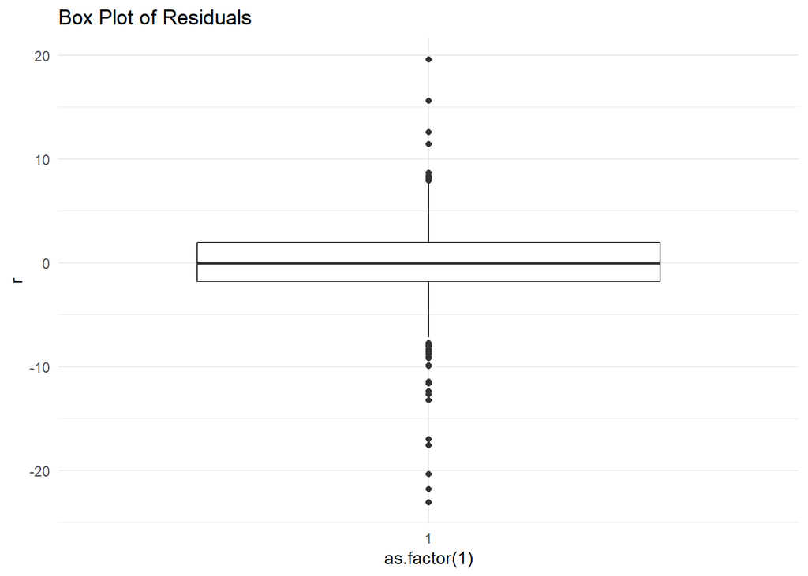

```r
ggplot(r,aes(y=r,x=as.factor(1)))+geom_boxplot()+ggtitle("Box Plot of Residuals")+theme_minimal()
```

Box Plot seems symmetric shape so we might say that it’s residuals are normally distributed but we should check.

```r
library(tseries)
jarque.bera.test(r)
```

```
##
##  Jarque Bera Test
##
## data:  r
## X-squared = 1018.2, df = 2, p-value < 2.2e-16
```

```r
shapiro.test(r)
```

```
##
##  Shapiro-Wilk normality test
##
## data:  r
## W = 0.91956, p-value < 2.2e-16
```

Since p value is less than alpha for both, we should reject Ho. Therefore,it can be said that we have no enough evidence to claim that we have residuals with normal distribution.

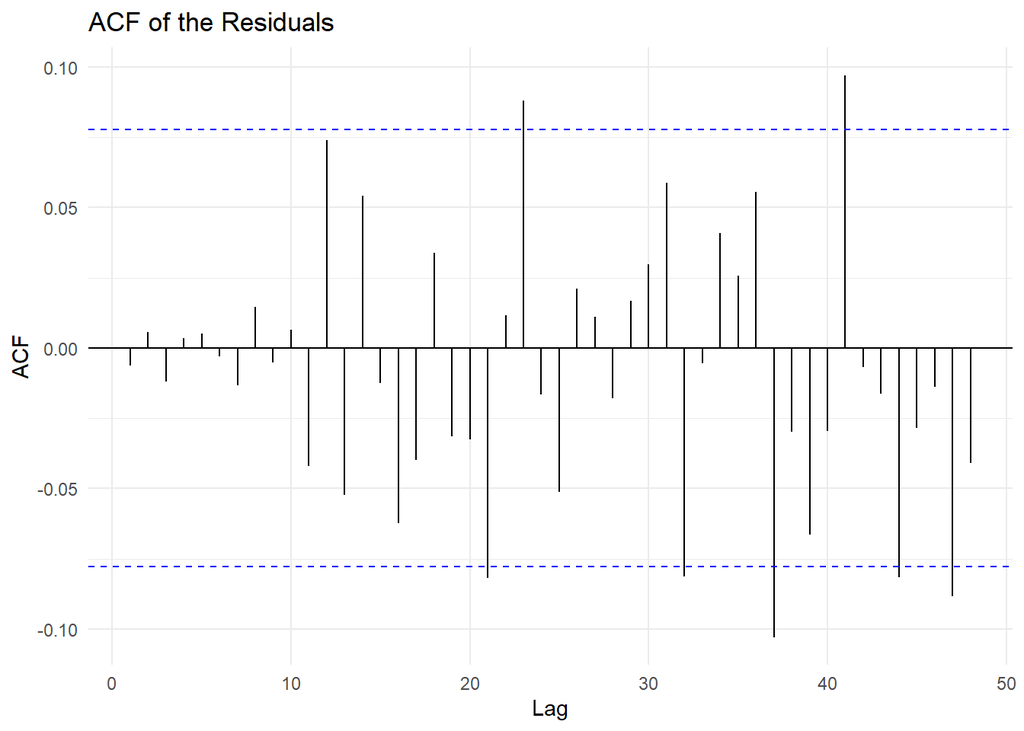

```r
ggAcf(as.vector(r),main="ACF of the Residuals",lag = 48)+theme_minimal() #to see time lags, as. factor function is used.
```

When we look to the residuals ACF most of them in the white noise band so the residuals are might be uncorrelated. To be sure we should make tests.

```r
library(TSA)
m = lm(r ~ 1+zlag(r))

library(lmtest)
bgtest(m,order=24)
```

```
##
##  Breusch-Godfrey test for serial correlation of order up to 24
##
## data:  m
## LM test = 24.588, df = 24, p-value = 0.4284
```

```r
Box.test(r,lag=24,type = c("Box-Pierce"))
```

```
##
##  Box-Pierce test
##
## data:  r
## X-squared = 23.661, df = 24, p-value = 0.4811
```

```r
Box.test(r,lag=24,type = c("Ljung-Box"))
```

```
##
##  Box-Ljung test
##
## data:  r
## X-squared = 24.403, df = 24, p-value = 0.4388
```

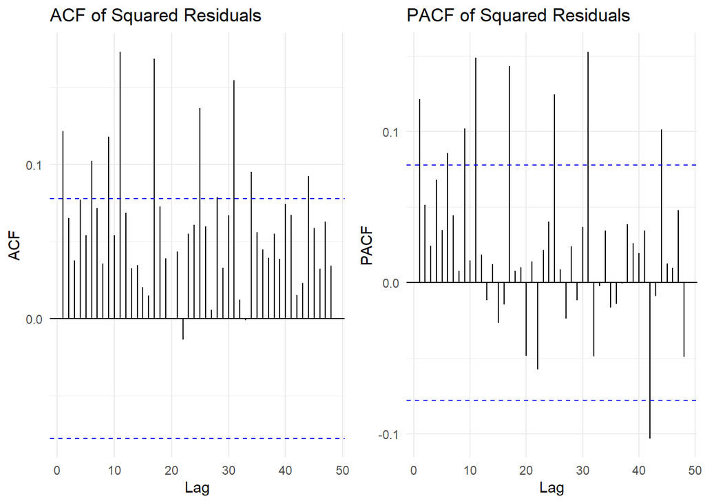

```r
#Detecting Heteroscedasticity
rr=r^2
g1<-ggAcf(as.vector(rr), lag.max = 48)+theme_minimal()+ggtitle("ACF of Squared Residuals")
g2<-ggPacf(as.vector(rr), lag.max = 48)+theme_minimal()+ggtitle("PACF of Squared Residuals")
grid.arrange(g1,g2,ncol=2)
```

There are some significant spikes so that it might be heteroscedastic to be sure let’s do some tests.

```r
library(lmtest)
m = lm(r ~ jpn_bc+zlag(jpn_bc)+zlag(jpn_bc,2))
bptest(m)
```

```
##
##  studentized Breusch-Pagan test
##
## data:  m
## BP = 48.446, df = 3, p-value = 1.711e-10
```

Since p value is smaller than 0.05, We reject Ho. Therefore, we can say that we have enough evidence to claim that there is heteroscedasticity, according to results of Breusch-Pagan test.

Also let’s check ARCH Engle’s Test to check heteroscedasticity.

```r
library(MTS)
library(FinTS)
ArchTest(rr)
```

```
##
##  ARCH LM-test; Null hypothesis: no ARCH effects
##
## data:  rr
## Chi-squared = 27.021, df = 12, p-value = 0.007675
```

```r
archTest(r)
```

```
## Q(m) of squared series(LM test):
## Test statistic:  40.51957  p-value:  1.372193e-05
## Rank-based Test:
## Test statistic:  141.2097  p-value:  0
```

Since p values is smaller than 0.05 , we reject H0. Therefore, we can conclude that there is presence of ARCH effects.

```r
library(rugarch)
spec=ugarchspec(variance.model = list(model="sGARCH",garchOrder = c(1, 1)))
def.fit1= ugarchfit(spec = spec, data = traindata_clean)
print(def.fit1)
```

```
##
## *---------------------------------*
## *          GARCH Model Fit        *
## *---------------------------------*
##
## Conditional Variance Dynamics
## -----------------------------------
## GARCH Model  : sGARCH(1,1)
## Mean Model   : ARFIMA(1,0,1)
## Distribution : norm
##
## Optimal Parameters
## ------------------------------------
##          Estimate  Std. Error   t value Pr(>|t|)
## mu     362.705834   10.995560   32.9866 0.000000
## ar1      1.000000    0.000723 1382.4094 0.000000
## ma1      0.299131    0.038443    7.7811 0.000000
## omega    0.067056    0.037578    1.7845 0.074349
## alpha1   0.039986    0.013569    2.9469 0.003210
## beta1    0.954337    0.013032   73.2327 0.000000
##
## Robust Standard Errors:
##          Estimate  Std. Error    t value Pr(>|t|)
## mu     362.705834   44.279745    8.19124  0.00000
## ar1      1.000000    0.000844 1184.31229  0.00000
## ma1      0.299131    0.041169    7.26593  0.00000
## omega    0.067056    0.070952    0.94509  0.34461
## alpha1   0.039986    0.036223    1.10388  0.26965
## beta1    0.954337    0.033442   28.53690  0.00000
##
## LogLikelihood : -1714.043
##
## Information Criteria
## ------------------------------------
##
## Akaike       5.4175
## Bayes        5.4595
## Shibata      5.4173
## Hannan-Quinn 5.4338
##
```

[output cut: 43 more lines]

```
## Negative Sign Bias  0.3772 0.7062
## Positive Sign Bias  0.0838 0.9332
## Joint Effect        0.3184 0.9565
##
##
## Adjusted Pearson Goodness-of-Fit Test:
## ------------------------------------
##   group statistic p-value(g-1)
## 1    20     38.10     0.005759
## 2    30     51.50     0.006188
## 3    40     52.56     0.072130
## 4    50     71.85     0.018368
##
##
## Elapsed time : 0.219945
```

```r
spec=ugarchspec(variance.model = list(model="sGARCH",garchOrder = c(2, 1)))
def.fit2= ugarchfit(spec = spec, data = traindata_clean)
print(def.fit2)
```

```
##
## *---------------------------------*
## *          GARCH Model Fit        *
## *---------------------------------*
##
## Conditional Variance Dynamics
## -----------------------------------
## GARCH Model  : sGARCH(2,1)
## Mean Model   : ARFIMA(1,0,1)
## Distribution : norm
##
## Optimal Parameters
## ------------------------------------
##          Estimate  Std. Error    t value Pr(>|t|)
## mu     358.004546    4.160851 8.6041e+01 0.000000
## ar1      1.000000    0.000735 1.3608e+03 0.000000
## ma1      0.299313    0.039086 7.6577e+00 0.000000
## omega    0.066663    0.038749 1.7204e+00 0.085362
## alpha1   0.039124    0.027046 1.4466e+00 0.148009
## alpha2   0.000000    0.029960 1.0000e-06 0.999999
## beta1    0.955055    0.011919 8.0131e+01 0.000000
##
## Robust Standard Errors:
##          Estimate  Std. Error    t value Pr(>|t|)
## mu     358.004546    0.213637 1.6758e+03  0.00000
## ar1      1.000000    0.000821 1.2181e+03  0.00000
## ma1      0.299313    0.041129 7.2775e+00  0.00000
## omega    0.066663    0.073965 9.0128e-01  0.36744
## alpha1   0.039124    0.029434 1.3292e+00  0.18377
## alpha2   0.000000    0.035252 1.0000e-06  1.00000
## beta1    0.955055    0.020074 4.7576e+01  0.00000
##
## LogLikelihood : -1713.542
##
## Information Criteria
## ------------------------------------
##
## Akaike       5.4190
## Bayes        5.4681
## Shibata      5.4188
```

[output cut: 46 more lines]

```
## Negative Sign Bias  0.4198 0.6748
## Positive Sign Bias  0.1043 0.9170
## Joint Effect        0.3507 0.9502
##
##
## Adjusted Pearson Goodness-of-Fit Test:
## ------------------------------------
##   group statistic p-value(g-1)
## 1    20     38.73     0.004783
## 2    30     53.02     0.004191
## 3    40     50.80     0.097758
## 4    50     76.10     0.007840
##
##
## Elapsed time : 0.1921341
```

```r
spec=ugarchspec(variance.model = list(model="sGARCH",garchOrder = c(2, 2)))
def.fit3= ugarchfit(spec = spec, data = traindata_clean)
print(def.fit3)
```

```
##
## *---------------------------------*
## *          GARCH Model Fit        *
## *---------------------------------*
##
## Conditional Variance Dynamics
## -----------------------------------
## GARCH Model  : sGARCH(2,2)
## Mean Model   : ARFIMA(1,0,1)
## Distribution : norm
##
## Optimal Parameters
## ------------------------------------
##          Estimate  Std. Error    t value Pr(>|t|)
## mu     357.982143    4.168590 8.5876e+01 0.000000
## ar1      1.000000    0.000715 1.3979e+03 0.000000
## ma1      0.295675    0.038076 7.7654e+00 0.000000
## omega    0.117424    0.075294 1.5595e+00 0.118869
## alpha1   0.072074    0.019496 3.6969e+00 0.000218
## alpha2   0.000000    0.015398 1.0000e-05 0.999992
## beta1    0.000000    0.029324 6.0000e-06 0.999995
## beta2    0.917370    0.027291 3.3615e+01 0.000000
##
## Robust Standard Errors:
##          Estimate  Std. Error    t value Pr(>|t|)
## mu     357.982143    0.258502 1.3848e+03 0.000000
## ar1      1.000000    0.000875 1.1424e+03 0.000000
## ma1      0.295675    0.037293 7.9284e+00 0.000000
## omega    0.117424    0.148188 7.9239e-01 0.428131
## alpha1   0.072074    0.033354 2.1609e+00 0.030707
## alpha2   0.000000    0.023214 6.0000e-06 0.999995
## beta1    0.000000    0.053105 3.0000e-06 0.999997
## beta2    0.917370    0.046097 1.9901e+01 0.000000
##
## LogLikelihood : -1706.355
##
## Information Criteria
## ------------------------------------
##
## Akaike       5.3995
```

[output cut: 49 more lines]

```
## Negative Sign Bias 0.03637 0.9710
## Positive Sign Bias 0.07237 0.9423
## Joint Effect       0.16589 0.9829
##
##
## Adjusted Pearson Goodness-of-Fit Test:
## ------------------------------------
##   group statistic p-value(g-1)
## 1    20     35.14      0.01343
## 2    30     48.20      0.01402
## 3    40     57.47      0.02849
## 4    50     66.81      0.04611
##
##
## Elapsed time : 0.2223959
```

```r
spec=ugarchspec(variance.model = list(model="apARCH"))
def.fit4= ugarchfit(spec = spec, data = traindata_clean)
print(def.fit4)
```

```
##
## *---------------------------------*
## *          GARCH Model Fit        *
## *---------------------------------*
##
## Conditional Variance Dynamics
## -----------------------------------
## GARCH Model  : apARCH(1,1)
## Mean Model   : ARFIMA(1,0,1)
## Distribution : norm
##
## Optimal Parameters
## ------------------------------------
##          Estimate  Std. Error    t value Pr(>|t|)
## mu     358.114317    6.139101   58.33335  0.00000
## ar1      0.999594    0.000851 1174.08471  0.00000
## ma1      0.308891    0.037532    8.23001  0.00000
## omega    0.029082    0.088820    0.32742  0.74335
## alpha1   0.001081    0.002683    0.40273  0.68715
## beta1    0.985946    0.001236  797.67606  0.00000
## gamma1  -0.830845    1.288673   -0.64473  0.51910
## delta    3.500000    0.438632    7.97936  0.00000
##
## Robust Standard Errors:
##          Estimate  Std. Error   t value Pr(>|t|)
## mu     358.114317    1.410513 253.88933 0.000000
## ar1      0.999594    0.001184 844.37221 0.000000
## ma1      0.308891    0.041003   7.53329 0.000000
## omega    0.029082    0.179314   0.16218 0.871161
## alpha1   0.001081    0.001873   0.57696 0.563967
## beta1    0.985946    0.001037 950.56723 0.000000
## gamma1  -0.830845    0.817584  -1.01622 0.309525
## delta    3.500000    0.908899   3.85081 0.000118
##
## LogLikelihood : -1701.633
##
## Information Criteria
## ------------------------------------
##
## Akaike       5.3847
```

[output cut: 49 more lines]

```
## Negative Sign Bias  1.3198 0.1874
## Positive Sign Bias  0.5937 0.5529
## Joint Effect        2.2188 0.5282
##
##
## Adjusted Pearson Goodness-of-Fit Test:
## ------------------------------------
##   group statistic p-value(g-1)
## 1    20     31.24      0.03803
## 2    30     44.23      0.03491
## 3    40     53.82      0.05748
## 4    50     57.36      0.19285
##
##
## Elapsed time : 4.061539
```

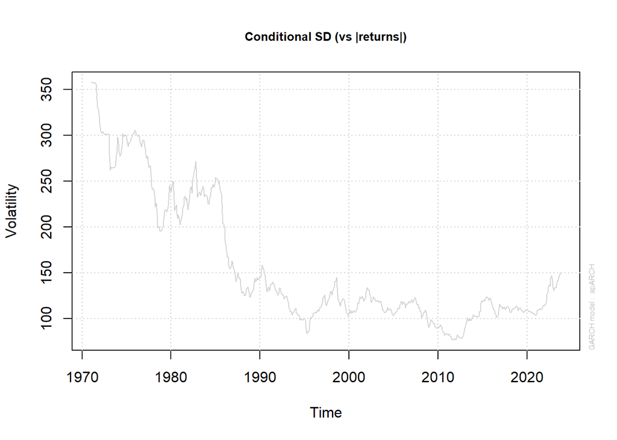

```r
plot(def.fit4,which=3)
```

```r
f<-ugarchforecast(def.fit4,n.ahead = 12)
f@forecast
```

```
## $n.ahead
## [1] 12
##
## $N
## [1] 635
##
## $n.start
## [1] 0
##
## $n.roll
## [1] 0
##
## $sigmaFor
##      Kas 2023
## T+1  2.758846
## T+2  2.756028
## T+3  2.753214
## T+4  2.750406
## T+5  2.747604
## T+6  2.744806
## T+7  2.742014
## T+8  2.739227
## T+9  2.736445
## T+10 2.733668
## T+11 2.730897
## T+12 2.728131
##
## $seriesFor
##      Kas 2023
## T+1  149.6547
## T+2  149.7394
## T+3  149.8240
## T+4  149.9086
## T+5  149.9931
## T+6  150.0777
## T+7  150.1622
## T+8  150.2466
## T+9  150.3310
## T+10 150.4154
## T+11 150.4998
## T+12 150.5841
```

```r
f@forecast$seriesFor
```

```
##      Kas 2023
## T+1  149.6547
## T+2  149.7394
## T+3  149.8240
## T+4  149.9086
## T+5  149.9931
## T+6  150.0777
## T+7  150.1622
## T+8  150.2466
## T+9  150.3310
## T+10 150.4154
## T+11 150.4998
## T+12 150.5841
```

```r
s<-as.vector(f@forecast$seriesFor)
bootp=ugarchboot(def.fit4,method=c("Partial","Full")[1],n.ahead = 12,n.bootpred=1000,n.bootfit=1000)
bootp
```

```
##
## *-----------------------------------*
## *     GARCH Bootstrap Forecast      *
## *-----------------------------------*
## Model : apARCH
## n.ahead : 12
## Bootstrap method:  partial
## Date (T[0]): Kas 2023
##
## Series (summary):
##         min   q.25   mean   q.75    max forecast[analytic]
## t+1  137.83 148.05 149.52 151.15 160.45             149.65
## t+2  131.96 146.81 149.45 152.26 166.83             149.74
## t+3  126.69 145.74 149.36 152.92 166.90             149.82
## t+4  125.76 145.12 149.39 153.54 171.64             149.91
## t+5  125.09 144.65 149.34 154.18 174.16             149.99
## t+6  123.33 143.96 149.12 154.64 174.90             150.08
## t+7  118.81 143.17 148.86 154.65 179.53             150.16
## t+8  115.64 142.79 148.87 155.44 180.06             150.25
## t+9  114.42 142.01 148.83 155.90 182.27             150.33
## t+10 113.78 141.33 148.64 156.13 188.34             150.42
## .....................
##
## Sigma (summary):
##         min  q0.25   mean  q0.75    max forecast[analytic]
## t+1  2.7588 2.7588 2.7588 2.7588 2.7588             2.7588
## t+2  2.7484 2.7484 2.7564 2.7492 3.3874             2.7560
## t+3  2.7380 2.7380 2.7514 2.7447 3.3742             2.7532
## t+4  2.7276 2.7277 2.7467 2.7393 3.3609             2.7504
## t+5  2.7173 2.7179 2.7446 2.7346 3.3491             2.7476
## t+6  2.7070 2.7083 2.7420 2.7286 3.3503             2.7448
## t+7  2.6968 2.6995 2.7372 2.7249 3.4742             2.7420
## t+8  2.6866 2.6906 2.7322 2.7224 3.4606             2.7392
## t+9  2.6764 2.6823 2.7298 2.7235 3.4617             2.7364
## t+10 2.6664 2.6746 2.7266 2.7206 3.4920             2.7337
## .....................
```

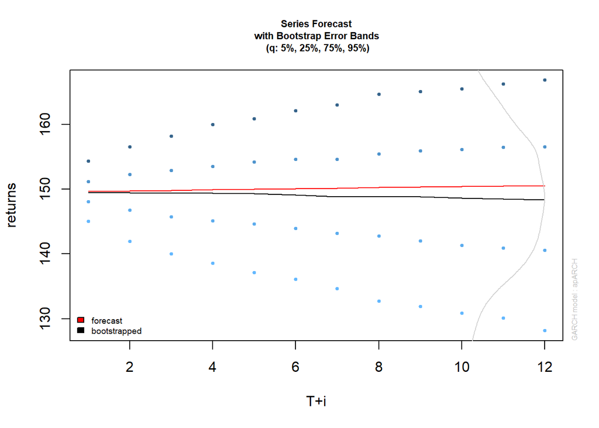

```r
plot(bootp,which=2)
```

Now, lets compare the performance of apARCH model with SARIMA model.

```r
s_f=bootp@forc@forecast$seriesFor #this is for series forecasts
s_f
```

```
##      Kas 2023
## T+1  149.6547
## T+2  149.7394
## T+3  149.8240
## T+4  149.9086
## T+5  149.9931
## T+6  150.0777
## T+7  150.1622
## T+8  150.2466
## T+9  150.3310
## T+10 150.4154
## T+11 150.4998
## T+12 150.5841
```

```r
s_f1=as.vector(s_f) #for comparison, we make the forecasts as vector.

v_f=bootp@forc@forecast$sigmaFor#this is for variance forecasts
v_f
```

```
##      Kas 2023
## T+1  2.758846
## T+2  2.756028
## T+3  2.753214
## T+4  2.750406
## T+5  2.747604
## T+6  2.744806
## T+7  2.742014
## T+8  2.739227
## T+9  2.736445
## T+10 2.733668
## T+11 2.730897
## T+12 2.728131
```

```r
f1<-forecast(fit5,h=12)
f1
```

```
##          Point Forecast    Lo 80    Hi 80    Lo 95    Hi 95
## Dec 2023       148.8785 143.7106 154.0465 140.9748 156.7822
## Jan 2024       149.4631 140.7034 158.2228 136.0663 162.8598
## Feb 2024       149.9154 138.5924 161.2384 132.5983 167.2324
## Mar 2024       149.6591 136.0583 163.2599 128.8585 170.4597
## Apr 2024       149.7498 134.0764 165.4232 125.7794 173.7202
## May 2024       150.5424 132.9080 168.1769 123.5729 177.5120
## Jun 2024       150.6852 131.3752 169.9951 121.1532 180.2171
## Jul 2024       150.7970 129.9708 171.6233 118.9460 182.6481
## Aug 2024       151.0171 128.6577 173.3765 116.8214 185.2129
## Sep 2024       151.3142 127.4267 175.2017 114.7815 187.8469
## Oct 2024       151.5317 126.3045 176.7589 112.9501 190.1133
## Nov 2024       151.4147 124.8323 177.9972 110.7604 192.0691
```

```r
accuracy(f1,test_data)
```

```
##                      ME     RMSE      MAE         MPE     MAPE      MASE
## Training set -0.1828380 3.994284 2.742203 -0.08307179 1.820122 0.1828795
## Test set      0.2250061 4.802443 4.078373  0.04672809 2.706794 0.2719896
##                      ACF1 Theil's U
## Training set -0.006269774        NA
## Test set      0.514463031  1.021692
```

```r
accuracy(s_f1,test_data)
```

```
##                 ME     RMSE      MAE       MPE     MAPE      ACF1 Theil's U
## Test set 0.5193128 4.893326 4.111728 0.2395626 2.723077 0.4985613  1.022809
```

```r
accuracy(s,test_data)
```

```
##                 ME     RMSE      MAE       MPE     MAPE      ACF1 Theil's U
## Test set 0.5193128 4.893326 4.111728 0.2395626 2.723077 0.4985613  1.022809
```

12- Part-A

Part-B

```r
library(forecast)
qcement.ets <- ets(train_data, model = "ZZZ")
summary(qcement.ets)
```

```
## ETS(M,Ad,N)
##
## Call:
## ets(y = train_data, model = "ZZZ")
##
##   Smoothing parameters:
##     alpha = 0.9999
##     beta  = 0.2649
##     phi   = 0.8
##
##   Initial states:
##     l = 369.921
##     b = -2.3253
##
##   sigma:  0.0251
##
##      AIC     AICc      BIC
## 5733.264 5733.398 5759.986
##
## Training set error measures:
##                     ME     RMSE      MAE         MPE     MAPE      MASE
## Training set -0.158578 4.230997 2.909112 -0.06807127 1.901818 0.1917649
##                   ACF1
## Training set 0.1318629
```

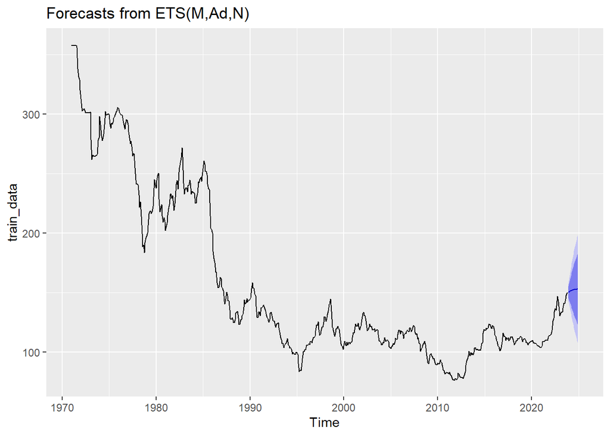

```r
qcement.f1 <- forecast(qcement.ets, h = 13)
autoplot(qcement.f1)
```

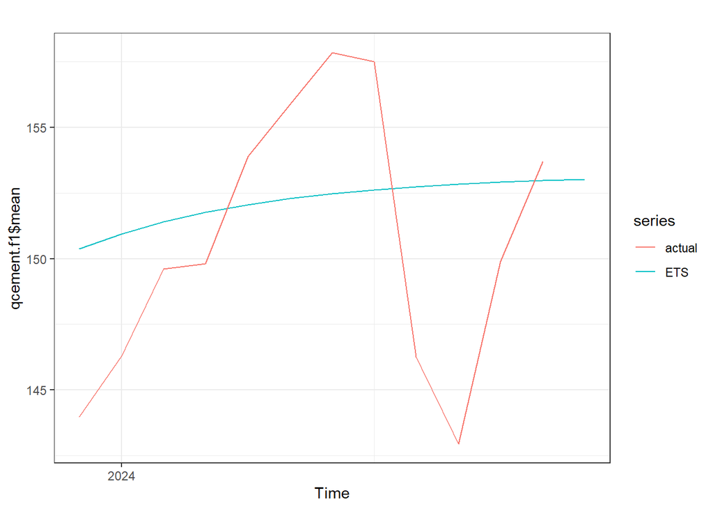

```r
autoplot(qcement.f1$mean, series = "ETS")+autolayer(test_data,series="actual")+theme_bw()
```

```r
accuracy(qcement.f1,test_data)
```

```
##                     ME     RMSE      MAE         MPE     MAPE      MASE
## Training set -0.158578 4.230997 2.909112 -0.06807127 1.901818 0.1917649
## Test set     -1.480747 4.900754 4.218139 -1.08428132 2.831379 0.2780542
##                   ACF1 Theil's U
## Training set 0.1318629        NA
## Test set     0.4969854  1.022349
```

PART-C nnetar

```r
nnmodel<-nnetar(traindata_clean)
nnmodel
```

```
## Series: traindata_clean
## Model:  NNAR(2,1,2)[12]
## Call:   nnetar(y = traindata_clean)
##
## Average of 20 networks, each of which is
## a 3-2-1 network with 11 weights
## options were - linear output units
##
## sigma^2 estimated as 15.94
```

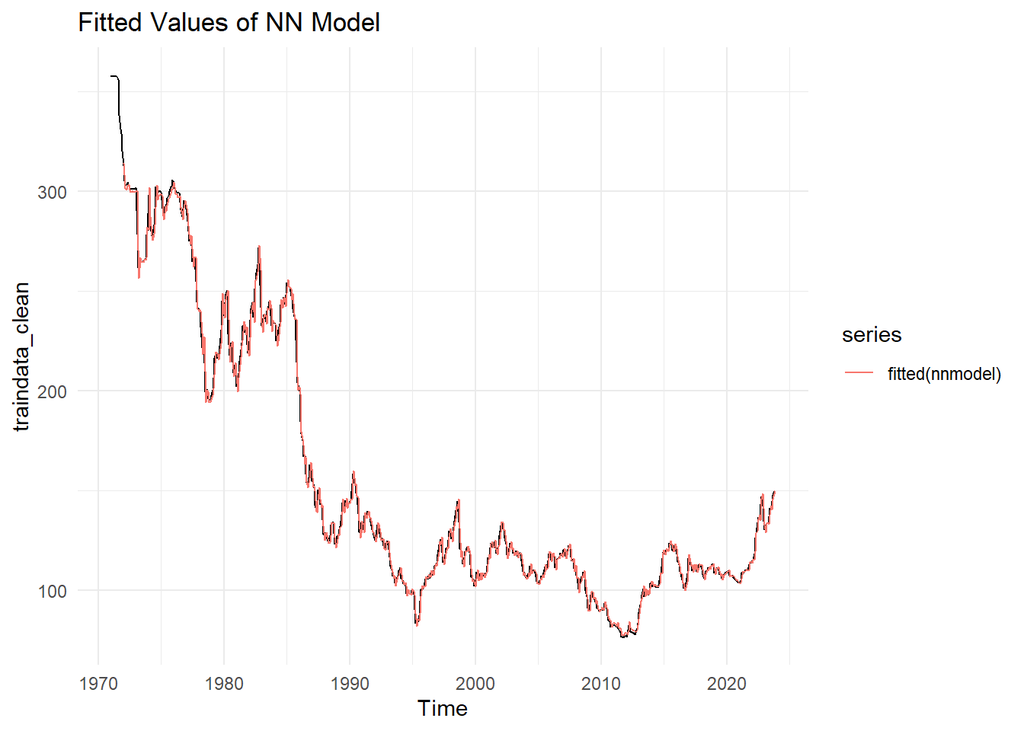

```r
autoplot(traindata_clean)+autolayer(fitted(nnmodel))+theme_minimal()+ggtitle("Fitted Values of NN Model")
```

```r
nnforecast<-forecast(nnmodel,h=12,PI=TRUE)
nnforecast
```

```
##          Point Forecast    Lo 80    Hi 80    Lo 95    Hi 95
## Dec 2023       149.6431 144.3588 155.0739 141.4354 158.0353
## Jan 2024       149.6392 141.4185 158.3999 136.3172 162.8279
## Feb 2024       149.6044 138.5759 160.4346 132.6615 167.0655
## Mar 2024       149.5500 136.5131 163.2891 129.2359 169.9572
## Apr 2024       149.4918 133.8922 165.8786 125.4655 172.3879
## May 2024       149.3757 131.3059 167.8367 122.5268 175.6442
## Jun 2024       149.1732 129.2601 169.7627 119.3610 179.3855
## Jul 2024       148.9477 127.8230 171.2856 117.7393 182.3277
## Aug 2024       148.6521 126.6586 173.4551 115.5402 183.7523
## Sep 2024       148.2834 125.0174 174.6672 112.7389 186.7043
## Oct 2024       147.8598 122.6103 175.8899 109.6123 188.8127
## Nov 2024       147.4113 121.7198 177.8657 107.4213 190.9370
```

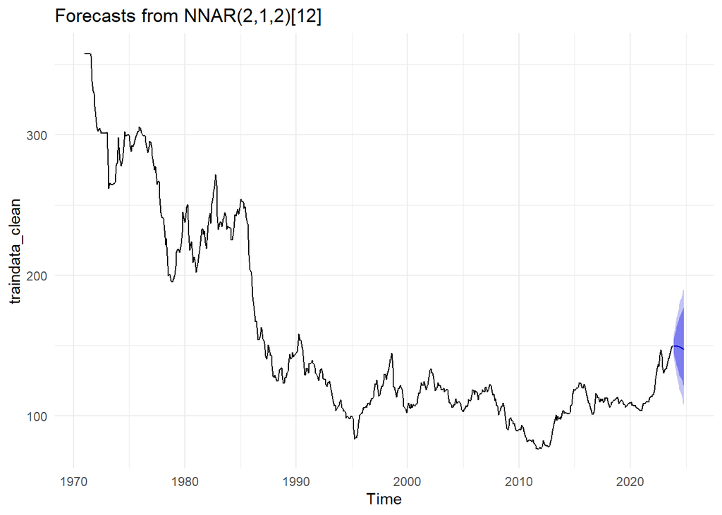

```r
autoplot(nnforecast)+theme_minimal()
```

```r
accuracy(nnforecast,test_data)
```

```
##                         ME     RMSE      MAE         MPE     MAPE      MASE
## Training set -0.0001780652 3.993087 2.780810 -0.06189707 1.864686 0.1854542
## Test set      1.6697145256 5.257324 4.457027  1.00243806 2.932319 0.2972423
##                    ACF1 Theil's U
## Training set 0.02809671        NA
## Test set     0.46463162  1.104277
```

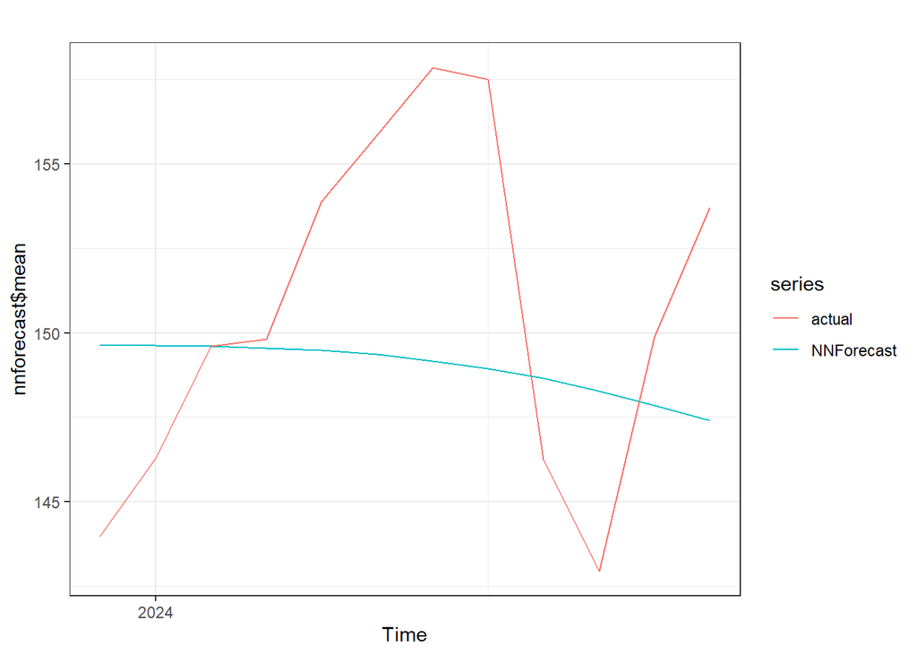

```r
autoplot(nnforecast$mean, series = "NNForecast")+autolayer(test_data,series="actual")+theme_bw()
```

PART-D TBATS

```r
tbatsmodel<-tbats(train_data)
tbatsmodel
```

```
## BATS(0.008, {0,0}, 0.91, -)
##
## Call: tbats(y = train_data)
##
## Parameters
##   Lambda: 0.007588
##   Alpha: 1.29785
##   Beta: 0.03527141
##   Damping Parameter: 0.91025
##
## Seed States:
##              [,1]
## [1,]  6.048597208
## [2,] -0.008413943
## attr(,"lambda")
## [1] 0.007587867
##
## Sigma: 0.02544959
## AIC: 5708.208
```

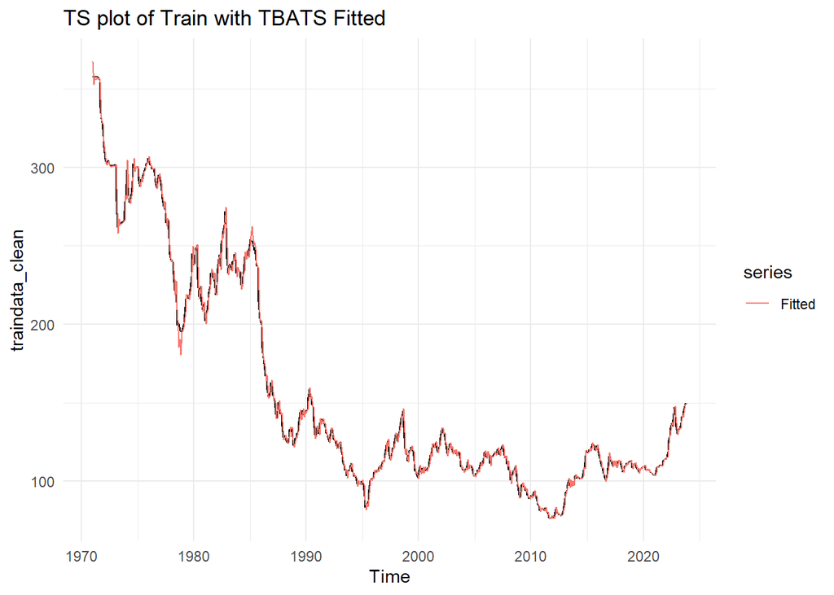

```r
autoplot(traindata_clean,main="TS plot of Train with TBATS Fitted") +autolayer(fitted(tbatsmodel), series="Fitted") +theme_minimal()
```

The model fitted values almost matchs with the true values of the series as shown in the figure.

```r
tbats_forecast<-forecast(tbatsmodel,h=12)
tbats_forecast
```

```
##          Point Forecast    Lo 80    Hi 80    Lo 95    Hi 95
## Dec 2023       149.8210 145.1894 154.5992 142.7954 157.1895
## Jan 2024       150.1011 142.4589 158.1500 138.5710 162.5828
## Feb 2024       150.3565 140.5458 160.8465 135.6123 166.6904
## Mar 2024       150.5894 138.9703 163.1720 133.1843 170.2496
## Apr 2024       150.8017 137.5881 165.2738 131.0651 173.4844
## May 2024       150.9952 136.3339 167.2199 129.1539 176.4973
## Jun 2024       151.1715 135.1724 169.0483 127.3953 179.3453
## Jul 2024       151.3322 134.0820 170.7828 125.7554 182.0636
## Aug 2024       151.4786 133.0487 172.4395 124.2119 184.6758
## Sep 2024       151.6120 132.0628 174.0299 122.7490 187.1985
## Oct 2024       151.7335 131.1175 175.5627 121.3554 189.6443
## Nov 2024       151.8442 130.2075 177.0447 120.0225 192.0225
```

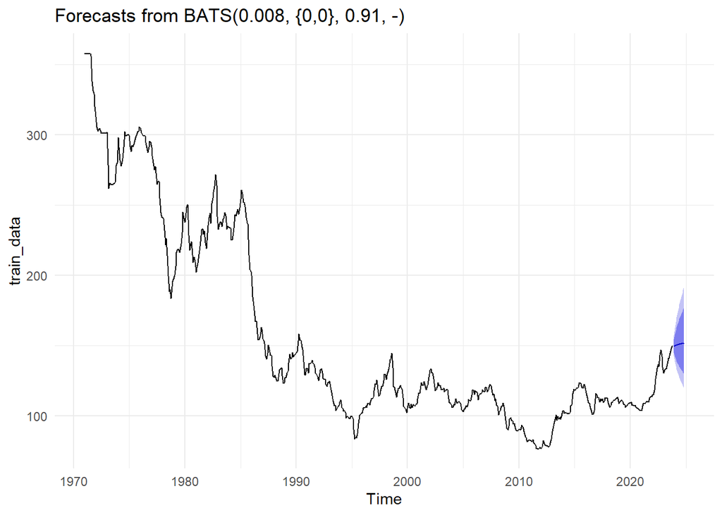

```r
autoplot(tbats_forecast)+theme_minimal()
```

we produced the 12 steps ahead forecast using forecast() function. The forecast plot shows that the prediction intervals appear to be not much too wide , it’s a bit narrow , This may indicate that the forecasts are accurate.

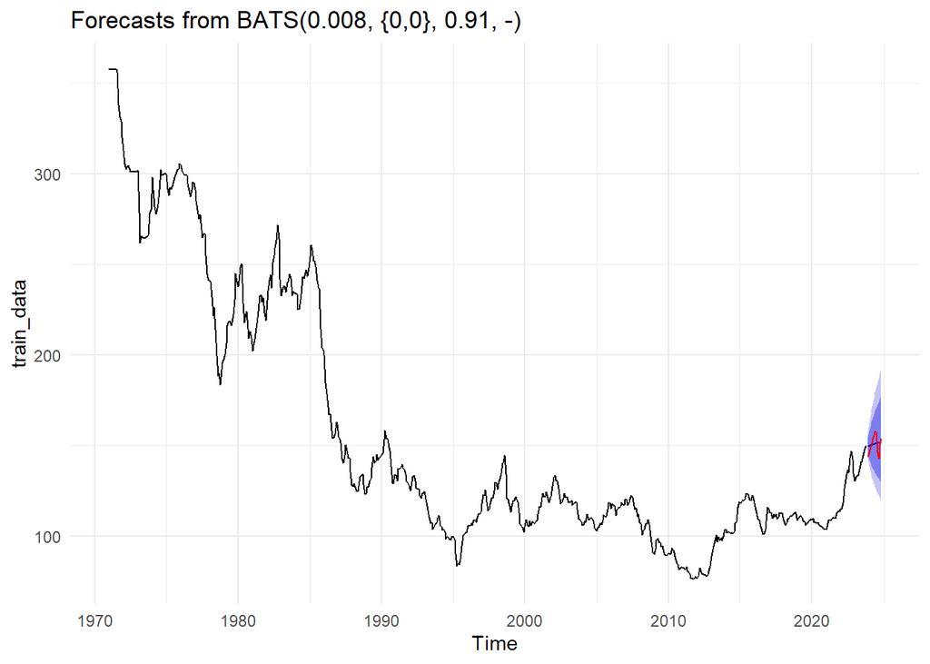

```r
autoplot(tbats_forecast)+autolayer(test_data,series="actual",color="red")+theme_minimal()
```

It is not accurate when we look to the red and blue line. So it is not accurate but let’s check accuracy.

```r
accuracy(tbats_forecast,test_data)
```

```
##                      ME     RMSE      MAE        MPE     MAPE      MASE
## Training set -0.2108889 4.116548 2.825408 -0.1062966 1.860950 0.1862472
## Test set     -0.3473901 4.787738 4.131573 -0.3337950 2.752696 0.2723479
##                    ACF1 Theil's U
## Training set 0.03049356        NA
## Test set     0.50245432  1.000441
```

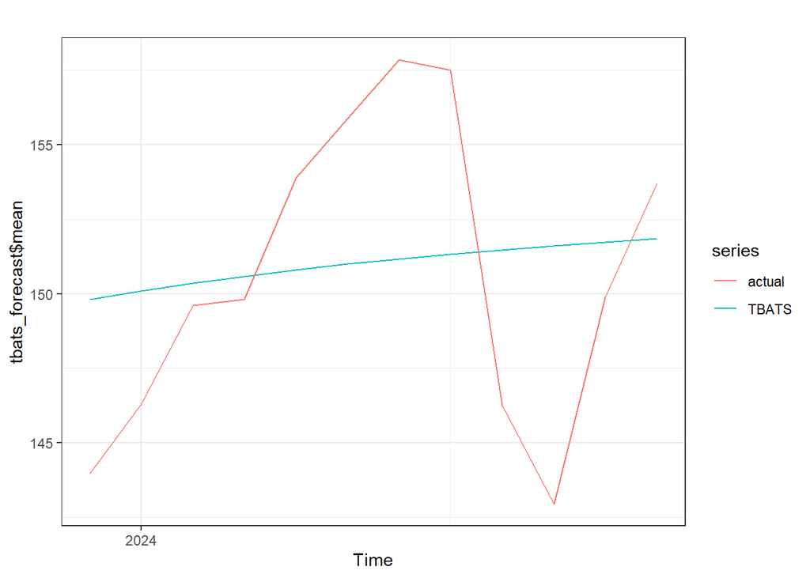

```r
autoplot(tbats_forecast$mean, series = "TBATS")+autolayer(test_data,series="actual")+theme_bw()
```

Part-E

```r
library(prophet)
ds<-c(seq(as.Date("1971/01/01"),as.Date("2023/11/01"),by="month"))
df<-data.frame(ds,y=as.numeric(train_data))
head(df)
```

```
##           ds        y
## 1 1971-01-01 358.0200
## 2 1971-02-01 357.5450
## 3 1971-03-01 357.5187
## 4 1971-04-01 357.5032
## 5 1971-05-01 357.4130
## 6 1971-06-01 357.4118
```

```r
jpn_prophet <- prophet(df)
```

```
## Disabling weekly seasonality. Run prophet with weekly.seasonality=TRUE to override this.
```

```
## Disabling daily seasonality. Run prophet with daily.seasonality=TRUE to override this.
```

```r
future<-make_future_dataframe(jpn_prophet,periods = 12)
tail(future)
```

```
##             ds
## 642 2023-11-08
## 643 2023-11-09
## 644 2023-11-10
## 645 2023-11-11
## 646 2023-11-12
## 647 2023-11-13
```

```r
dim(df)
```

```
## [1] 635   2
```

```r
dim(future)
```

```
## [1] 647   1
```

```r
#
```

```r
forecast <- predict(jpn_prophet, future)
tail(forecast[c('ds', 'yhat', 'yhat_lower', 'yhat_upper')],12)
```

```
##             ds      yhat yhat_lower yhat_upper
## 636 2023-11-02 123.62268   97.49989   146.5833
## 637 2023-11-03 120.19081   99.54676   145.2607
## 638 2023-11-04 116.75983   93.66703   140.7297
## 639 2023-11-05 113.39802   89.63808   135.4684
## 640 2023-11-06 110.17262   84.87955   135.1303
## 641 2023-11-07 107.14816   83.25973   130.1516
## 642 2023-11-08 104.38479   81.10069   129.4579
## 643 2023-11-09 101.93677   78.29046   125.4460
## 644 2023-11-10  99.85105   76.16615   124.2810
## 645 2023-11-11  98.16610   73.85221   121.7203
## 646 2023-11-12  96.91090   71.78557   120.9816
## 647 2023-11-13  96.10418   73.15051   118.2039
```

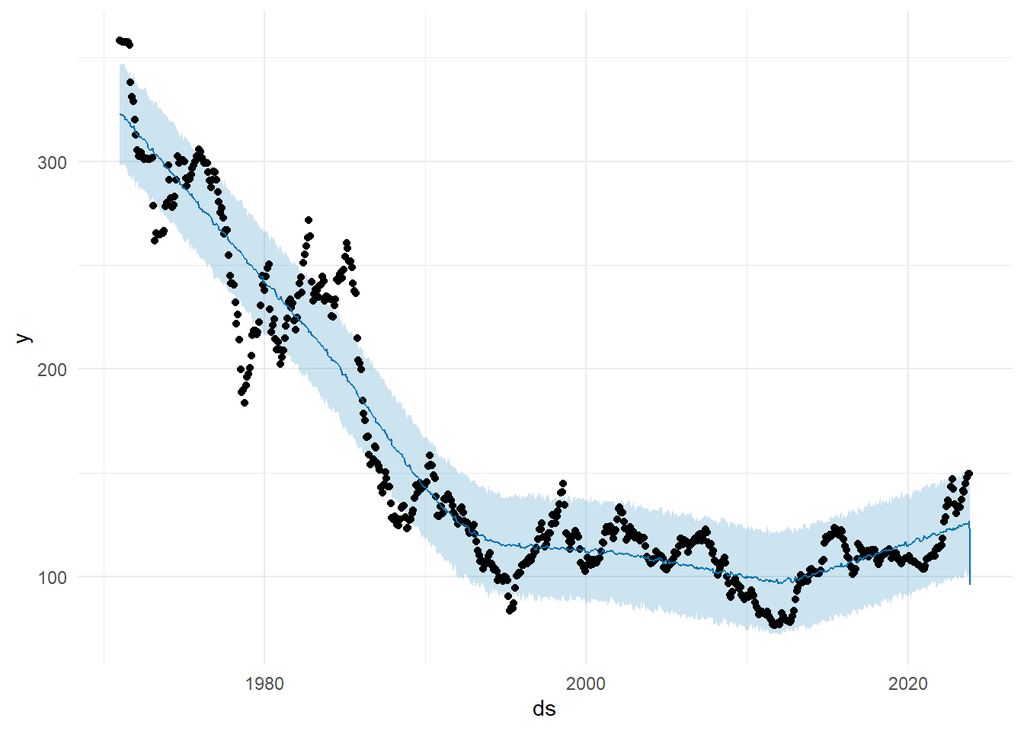

```r
library(ggplot2)
plot(jpn_prophet, forecast)+theme_minimal() #to see plot
```

Above graph shows the forecasted values of the data where, Black dots refers to the original data, Dark blue line refers to the predicted value(yhat), and Light blue area indicates the yhat_upper and yhat_lower value.

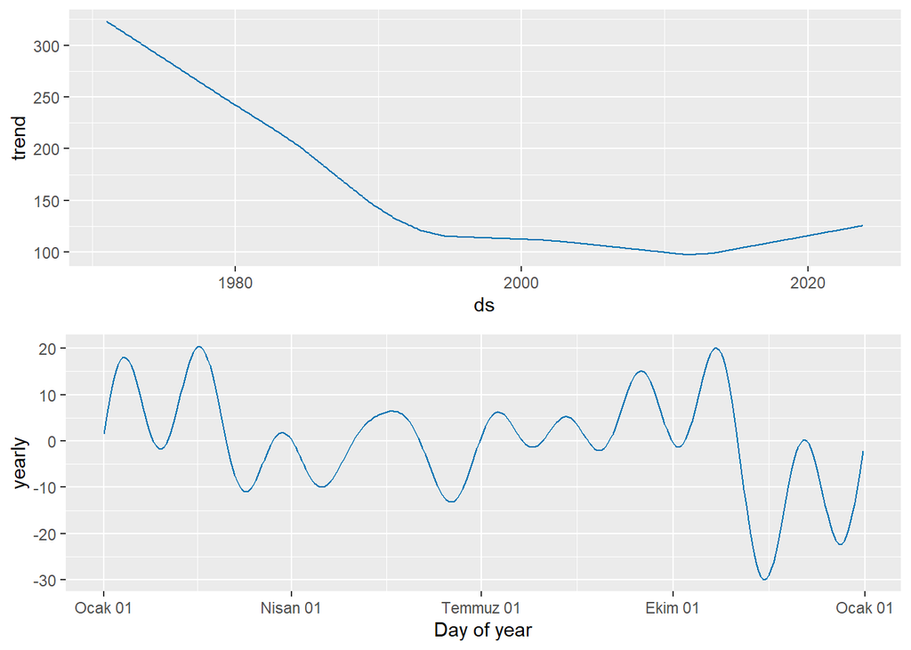

```r
prophet_plot_components(jpn_prophet, forecast)
```

```r
dyplot.prophet(jpn_prophet, forecast)
```

[interactive chart not shown]

We can use check the predicted vs real values and I think is not that great.

D- We can say that ETS outperforms prophet.

```r
jpn_prophet_new <- prophet(df,changepoint.range=0.5,changepoint.prior.scale=0.2,seasonality.prior.scale=0.7)
```

```
## Disabling weekly seasonality. Run prophet with weekly.seasonality=TRUE to override this.
```

```
## Disabling daily seasonality. Run prophet with daily.seasonality=TRUE to override this.
```

```r
future_new=make_future_dataframe(jpn_prophet_new,periods = 12, freq = "month")
forecast_new <- predict(jpn_prophet_new, future_new)
accuracy(tail(forecast_new$yhat,12),test_data)
```

```
##                ME     RMSE      MAE      MPE     MAPE      ACF1 Theil's U
## Test set 41.00977 41.29295 41.00977 27.14992 27.14992 0.4490775  9.003496
```

```r
library(prophet)
library(forecast)

changepoint_prior <- c(0.1, 0.5, 0.9)
seasonality_prior <- c(0.1, 0.3, 0.5)
changepoint_range <- c(0.6, 0.8, 0.9)

results <- data.frame(
  changepoint_prior = numeric(),
  seasonality_prior = numeric(),
  changepoint_range = numeric(),
  RMSE = numeric()
)

for (cp in changepoint_prior) {
  for (sp in seasonality_prior) {
    for (cr in changepoint_range) {
      m <- prophet(
        changepoint.prior.scale = cp,
        seasonality.prior.scale = sp,
        changepoint.range = cr
      )
      m <- fit.prophet(m, df)


      future <- make_future_dataframe(m, periods = 12, freq = "month")
      forecast <- predict(m, future)

      predicted <- tail(forecast$yhat, 12)
      acc <- accuracy(predicted, test_data)
      rmse <- acc["Test set", "RMSE"]  # Extract RMSE from accuracy

      results <- rbind(results, data.frame(
        changepoint_prior = cp,
        seasonality_prior = sp,
        changepoint_range = cr,
        RMSE = rmse
      ))
    }
  }
}
```

[output not shown]

[output not shown]

[output not shown]

[output not shown]

[output not shown]

[output not shown]

[output not shown]

[output not shown]

[output not shown]

[output not shown]

[output not shown]

[output not shown]

[output not shown]

[output not shown]

[output not shown]

[output not shown]

[output not shown]

[output not shown]

[output not shown]

[output not shown]

[output not shown]

[output not shown]

[output not shown]

[output not shown]

[output not shown]

[output not shown]

[output not shown]

[output not shown]

[output not shown]

[output not shown]

[output not shown]

[output not shown]

[output not shown]

[output not shown]

[output not shown]

[output not shown]

[output not shown]

[output not shown]

[output not shown]

[output not shown]

[output not shown]

[output not shown]

[output not shown]

[output not shown]

[output not shown]

[output not shown]

[output not shown]

[output not shown]

[output not shown]

[output not shown]

[output not shown]

[output not shown]

[output not shown]

[output not shown]

```r
#best parameters
best_params <- results[which.min(results$RMSE), ]
best_params
```

```
##    changepoint_prior seasonality_prior changepoint_range     RMSE
## 21               0.9               0.1               0.9 12.78779
```

```r
jpn_prophet_new2 <- prophet(df,changepoint.range=0.9,changepoint.prior.scale=0.1,seasonality.prior.scale=0.1)
```

```
## Disabling weekly seasonality. Run prophet with weekly.seasonality=TRUE to override this.
```

```
## Disabling daily seasonality. Run prophet with daily.seasonality=TRUE to override this.
```

```r
future_new2=make_future_dataframe(jpn_prophet_new2,periods = 12, freq = "month")
forecast_new2 <- predict(jpn_prophet_new2, future_new2)
accuracy(tail(forecast_new2$yhat,12),test_data)
```

```
##               ME     RMSE     MAE      MPE     MAPE      ACF1 Theil's U
## Test set 20.4826 21.03367 20.4826 13.51098 13.51098 0.4989271  4.601751
```

We obtained the smaller RMSE value compared to the original prophet model.

13-

```r
f1 <- forecast::forecast(fit5, h=12)
#f11<-InvBoxCox(f1$mean,lambda) #Back Transformation
#summary(f1)
#accuracy(f11,test_data)
accuracy(f1,test_data)
```

```
##                      ME     RMSE      MAE         MPE     MAPE      MASE
## Training set -0.1828380 3.994284 2.742203 -0.08307179 1.820122 0.1828795
## Test set      0.2250061 4.802443 4.078373  0.04672809 2.706794 0.2719896
##                      ACF1 Theil's U
## Training set -0.006269774        NA
## Test set      0.514463031  1.021692
```

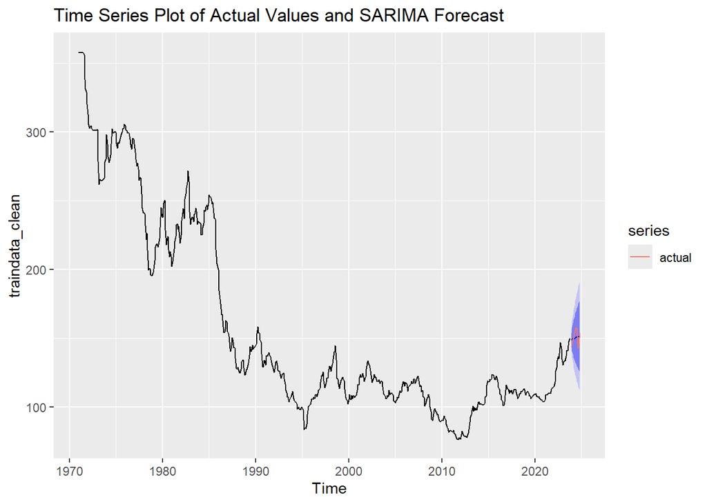

```r
autoplot(f1,main=c("Time Series Plot of Actual Values and SARIMA Forecast"), series="forecast" ) + autolayer(test_data,series = "actual")
```

14-

```r
accuracy(f1,test_data)
```

```
##                      ME     RMSE      MAE         MPE     MAPE      MASE
## Training set -0.1828380 3.994284 2.742203 -0.08307179 1.820122 0.1828795
## Test set      0.2250061 4.802443 4.078373  0.04672809 2.706794 0.2719896
##                      ACF1 Theil's U
## Training set -0.006269774        NA
## Test set      0.514463031  1.021692
```

```r
accuracy(tail(forecast_new2$yhat,12),test_data)
```

```
##               ME     RMSE     MAE      MPE     MAPE      ACF1 Theil's U
## Test set 20.4826 21.03367 20.4826 13.51098 13.51098 0.4989271  4.601751
```

```r
accuracy(s_f1,test_data)
```

```
##                 ME     RMSE      MAE       MPE     MAPE      ACF1 Theil's U
## Test set 0.5193128 4.893326 4.111728 0.2395626 2.723077 0.4985613  1.022809
```

```r
accuracy(s,test_data)
```

```
##                 ME     RMSE      MAE       MPE     MAPE      ACF1 Theil's U
## Test set 0.5193128 4.893326 4.111728 0.2395626 2.723077 0.4985613  1.022809
```

```r
accuracy(qcement.f1,test_data)
```

```
##                     ME     RMSE      MAE         MPE     MAPE      MASE
## Training set -0.158578 4.230997 2.909112 -0.06807127 1.901818 0.1917649
## Test set     -1.480747 4.900754 4.218139 -1.08428132 2.831379 0.2780542
##                   ACF1 Theil's U
## Training set 0.1318629        NA
## Test set     0.4969854  1.022349
```

```r
accuracy(nnforecast,test_data)
```

```
##                         ME     RMSE      MAE         MPE     MAPE      MASE
## Training set -0.0001780652 3.993087 2.780810 -0.06189707 1.864686 0.1854542
## Test set      1.6697145256 5.257324 4.457027  1.00243806 2.932319 0.2972423
##                    ACF1 Theil's U
## Training set 0.02809671        NA
## Test set     0.46463162  1.104277
```

```r
accuracy(tbats_forecast,test_data)
```

```
##                      ME     RMSE      MAE        MPE     MAPE      MASE
## Training set -0.2108889 4.116548 2.825408 -0.1062966 1.860950 0.1862472
## Test set     -0.3473901 4.787738 4.131573 -0.3337950 2.752696 0.2723479
##                    ACF1 Theil's U
## Training set 0.03049356        NA
## Test set     0.50245432  1.000441
```

15-

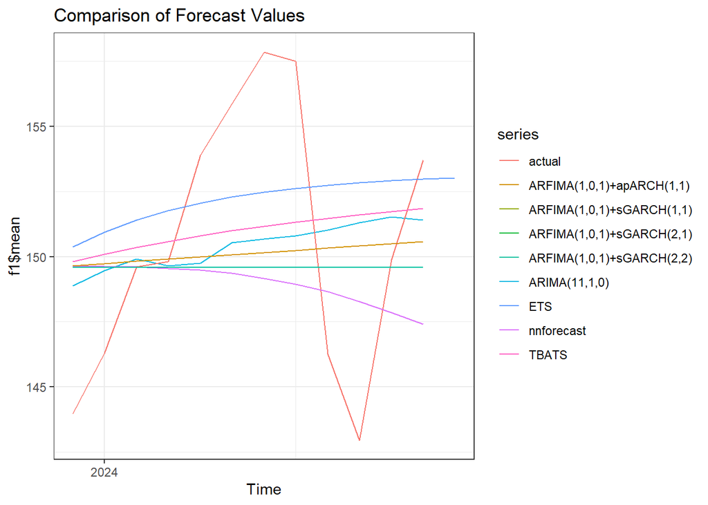

```r
boot_2 <- ugarchboot(def.fit4,method=c("Partial","Full")[1],n.ahead = 12,n.bootpred=1000,n.bootfit=1000)

f_2 <- boot_2@forc@forecast$seriesFor
f_vec_2 <- as.vector(f_2)

boot_1 <- ugarchboot(def.fit1,method=c("Partial","Full")[1],n.ahead = 12,n.bootpred=1000,n.bootfit=1000)

f_1 <- boot_1@forc@forecast$seriesFor
f_vec_1 <- as.vector(f_1)

boot <- ugarchboot(def.fit2,method=c("Partial","Full")[1],n.ahead = 12,n.bootpred=1000,n.bootfit=1000)

f_3 <- boot@forc@forecast$seriesFor
f_vec_3 <- as.vector(f_3)

boot_3 <- ugarchboot(def.fit3,method=c("Partial","Full")[1],n.ahead = 12,n.bootpred=1000,n.bootfit=1000)

f_4 <- boot_3@forc@forecast$seriesFor
f_vec_4 <- as.vector(f_4)

ts_garch <- ts(f_1, frequency = 12, start = c(2023, 12))
ts_garch_1 <- ts(f_3, frequency = 12, start = c(2023,12))
ts_garch_2 <- ts(f_4, frequency = 12, start = c(2023,12))
ts_aparch <- ts(f_2, frequency = 12, start = c(2023,12))


autoplot(f1$mean, series = "ARIMA(11,1,0)", main = "Comparison of Forecast Values") +
  autolayer(test_data, series = "actual") +
  autolayer(tbats_forecast$mean, series = "TBATS") +
  autolayer(nnforecast$mean, series = "nnforecast") +
   autolayer(qcement.f1$mean, series = "ETS")+autolayer(ts_aparch, series = "ARFIMA(1,0,1)+apARCH(1,1)")+autolayer(ts_garch, series = "ARFIMA(1,0,1)+sGARCH(1,1)")+autolayer(ts_garch_1, series = "ARFIMA(1,0,1)+sGARCH(2,1)")+autolayer(ts_garch_2, series = "ARFIMA(1,0,1)+sGARCH(2,2)")+theme_bw()
```

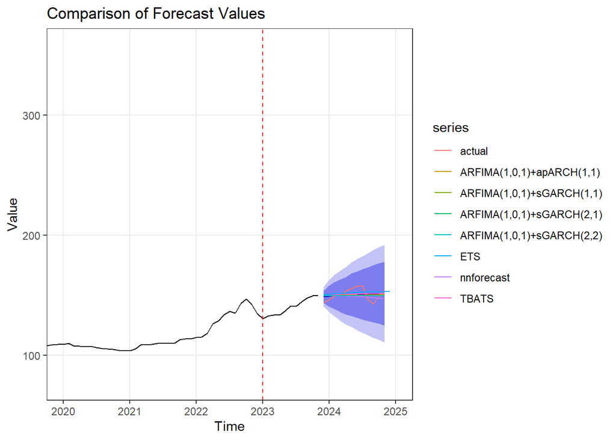

```r
autoplot(f1, series = "ARIMA(11,1,0)", main = "Comparison of Forecast Values") +
  autolayer(test_data, series = "actual") +
    autolayer(tbats_forecast$mean, series = "TBATS") +
  autolayer(nnforecast$mean, series = "nnforecast") +
   autolayer(qcement.f1$mean, series = "ETS")+autolayer(ts_aparch, series = "ARFIMA(1,0,1)+apARCH(1,1)")+autolayer(ts_garch, series = "ARFIMA(1,0,1)+sGARCH(1,1)")+autolayer(ts_garch_1, series = "ARFIMA(1,0,1)+sGARCH(2,1)")+autolayer(ts_garch_2, series = "ARFIMA(1,0,1)+sGARCH(2,2)")+theme_bw()+coord_cartesian(xlim = c(2020, 2025)) +
  geom_vline(xintercept = 2023,
             linetype = "dashed",
             color = "red")+theme(panel.grid.minor = element_blank()) +
  labs(x = "Time", y = "Value") +
  scale_x_continuous(breaks = seq(2020, 2025, by = 1))
```